# Operating Characteristics of Multiplier Resampling (MR) — FB / MR (IJ) / MR (field) combined

Estimation/coverage on the León (2024) Table 2 design, with the field-calibrated interval (TASK_mr_field_section7_2026-09-05)

Author

Larry León

Published

September 7, 2026

> **Status — combined FB / MR (IJ) / MR (field) template** (`TASK_mr_field_section7_2026-09-05`). Derived from the committed `sim_fs_maxeffCons_fb_mr_m1_h10_knoise0_n500_batch_1_1000.qmd` with knob deltas only: `ci_method = "field"` (the debiased element keeps the IJ interval, so the MR (IJ) columns are unchanged; the field block is recorded alongside), an `fb_mode` knob (`"run"` computes FB in-replicate; `"join"` reads a committed FB bundle and joins by `sim_id`, never recomputing FB; `"none"` skips it), and a `campaign_tag` in the output stem so this template can never write into an existing stem (the h-tag is also widened to three digits, `h100`/`h175`, closing the `round(10*1.75) = round(10*1.8) = 18` collision). Every knob can be overridden per render through `FS_S7_*` environment variables (see Section 4), so batches run from ONE committed file. `run_mode` and `sim_id_start` split a long run into seed-disjoint batches that combine later; `run_mode = "combine"` renders every table on the pooled set. `FS_S7_FIELD_COMPLEMENT=TRUE` adds the complement’s field block (`fld_Hc_*`, one-sided **upper** bound primary; `TASK_mr_field_complement_2026-09-06`); off by default, in which case the bundle is byte-identical to a pre-complement render.

# 1 What this evaluates

**Multiplier resampling (MR)** (`fs_mr_inference()`, surfaced through `forestsearch(mr_inference = TRUE)`) is a refit-free multiplier-bootstrap approximation of León’s post-selection bias correction, with an infinitesimal-jackknife (IJ) confidence interval. To first order its point estimate equals León’s Eq. 7 correction and its interval equals León’s IJ variance, the only approximation being the per-subgroup `dfbeta` linearization.

This document turns the single-trial validation into operating characteristics by re-running the León (2024) estimation/coverage design and recording, **per replicate on the same data and the same selected subgroup**:

- **oracle** $\hat\theta(H)$ — refit on the *true* harm subgroup;
- **naive** $\hat\theta(\hat H)$ — plugin on the identified subgroup;
- **FB** $\hat\theta^{*}(\hat H)$ — full nonparametric bootstrap bias-correction (`forestsearch_bootstrap_dofuture()`, León Eq. 7, the `H2` variant accounting for both bias sources) with its IJ interval;
- **MR** $\tilde\theta(\hat H)$ — refit-free multiplier resampling, holding the fitted candidate family fixed, with its IJ interval.

# 2 The true subgroup

Everything below is scored against one planted region, so it is stated first.

**Why this region.** GBSG is a node-positive breast-cancer cohort, and `er`/`meno` are the two covariates that jointly define endocrine responsiveness: hormone-receptor status and menopausal status are the standard axes on which adjuvant endocrine benefit is expected to differ. Planting harm in the ER-low, premenopausal corner therefore makes the target clinically coherent rather than an arbitrary covariate pair, and its ~12% prevalence puts it in the small-subgroup regime that stresses the large-sample behaviour of the correction — which is the point of the exercise.

**The near-tie this creates.** `age` correlates with `meno` strongly enough to substitute for it, so the search can return $\{\mathrm{er}\} \cap \{\mathrm{age}\}$ in place of $\{\mathrm{er}\} \cap \{\mathrm{meno}\}$ at nearly equal fit. Section 16 quantifies how often it does, and whether more data resolves it.

# 3 Endpoints, subgroups, and the harm convention

**Endpoint.** `simulate_from_dgm()` emits a time-to-event pair: `y_sim` (the event or censoring time, months) with indicator `event_sim`. Survival times come from the AFT model fitted to the GBSG covariate template; censoring is Weibull, scaled by `cens_adjust = log(1.5)`, with administrative censoring at `analysis_time = 84` months. Treatment is `treat_sim`, randomised 1:1.

**Effect measure.** The Cox hazard ratio of treatment, estimated within a region by `coxph(Surv(y_sim, event_sim) ~ treat_sim)`. Model SEs (`*_se` columns) are on the **log**-hazard-ratio scale while point estimates and interval bounds are on the **HR** scale; the estimation table reports $\text{SD}_{\beta}$ and $\widehat{\text{SD}}_{\beta}$ on the log scale and hides the HR-scale twins.

**Harm.** On a hazard ratio, larger is worse: $\text{HR} > 1$ means treatment raises the hazard, so **harm is HR > 1** and the null is HR = 1. Nothing is re-oriented on this path — every estimator column, every interval bound, and every target is on the natural HR scale as fitted. (The continuous twin *does* re-orient, because its raw scale runs the other way; see its matching section.)

The **oracle** is the only estimator fitted on $Q$; naive, FB and MR are all fitted on $\widehat H$. That is why the oracle’s meaningful comparisons are against the true-region targets and not against $\beta(\widehat H)$.

**The four targets** each estimator is scored against, in the notation the estimation table uses: $\hat\theta(H)$ the per-replicate oracle; $\beta(\widehat H)$ the population effect at the *realized* region (the Theorem 2 target, and the only one that moves with $\widehat H$); $\theta^{\ddagger}$ the CDE at $Q$; and $\theta^{\dagger}$ the marginal effect at $Q$. The last two differ here because the hazard ratio is non-collapsible.

## 3.1 How “MR flags harm in x%” is computed

The estimation-table footnote reports the share of replicates in which MR **confirms** harm. That is a decision, not an estimate, and it is separate from the interval: it asks whether the *de-biased* effect still points at harm after the selection correction, which is exactly the question the naive estimate cannot answer.

**The rule.** `fs_mr_inference()` de-biases the naive subgroup effect, then applies one comparison on the working scale (`fs_mr_inference.R`):

```
t_cmp    <- if (log_scale) log(t_confirm) else t_confirm
ci_lo_1s <- beta_deb - qnorm(0.95) * se
flag     <- if (confirm_rule == "point") (beta_deb >= t_cmp)
            else                          (ci_lo_1s >= t_cmp)
```

`beta_deb` is the de-biased estimate and `se` the interval SE (the IJ SE under `ci_method = "ij"`). So `"point"` asks whether the de-biased **point estimate** clears the threshold, and `"ci"` asks whether the one-sided 95% selection-adjusted **lower bound** does — strictly the more conservative of the two. The result is `harm_flag`, surfaced on the fitted object as `mr_harm_confirmed` and recorded here as `mr_harm_flag`.

**The threshold, and why it sits at the null.** On this path the effect measure is the hazard ratio, so the working scale is the **log** scale and `t_confirm` is compared as `log(t_confirm)`. Leaving `mr_t_confirm = NULL` takes the package’s near-null default, `t_confirm = 1` for ratio measures, so by default the question is “is the de-biased hazard ratio still at or above 1?” — *not* whether it still clears the screening threshold used during the search. That distinction is deliberate and `fs_mr_inference()` documents the reason: the de-biasing correction over-shrinks true effects, so testing against a screening-level threshold would reject genuine subgroups. Raising it to, say, `mr_t_confirm <- 1.10` would demand a de-biased HR of at least 1.10 before harm is called.

**Three-valued, and why that matters for the percentage.** `harm_flag` is `TRUE`, `FALSE`, or `NA`, the last when MR ran but bailed before it could compute one. The package documentation is explicit that `NA` here is *absence of evidence, not evidence against harm*, and warns against `isTRUE()`, which collapses `NA` to `FALSE`. This document records the flag three-valued and the reported percentage is `mean(..., na.rm = TRUE)`, so those replicates leave the denominator rather than entering it as “harm not confirmed”.

**Controlling it.** Both settings are knobs in Section 4 — `mr_t_confirm` and `mr_confirm_rule` — assembled into `mr_inference_args` and passed to `forestsearch(mr_inference_args = ...)`. `mr_t_confirm` is on the **effect** scale, not the working log scale; the code takes the log internally for ratio measures. The settings actually used are echoed in Section 8, after the run, so what is reported is what was used rather than what was intended.

# 4 Setup — all knobs

```r
.t0_doc <- Sys.time()    # start of document-level wall-clock (total reported at the very end)

# NOTE: forestsearch must be INSTALLED (devtools::install()), not load_all():
# the doFuture multisession workers spawn separate R processes that only see the
# installed package.
library(forestsearch)
library(survival)
library(data.table)
library(gt)
library(ggplot2)
library(foreach)
library(doFuture)
library(future)

# Parallelization topology (works with run_mode / batching above):
#   "sims"  -> replicates fan out across workers; each replicate's forestsearch +
#              bootstrap run sequentially.  Best when n_sims >= n_workers (fills cores).
#   "boots" -> replicates run sequentially; the forestsearch search AND the nb_boots
#              bootstrap fan out across workers WITHIN each replicate.  Best when
#              n_sims is small (single-/few-trial deep dives) and "sims" would idle cores.
# Bootstrap resample indices are seeded on the main process, so results are
# plan-invariant: the two modes differ in WALL-CLOCK only, not in detection/estimates.
parallel_mode <- "sims"

# ── Environment overrides (FS_S7_*) ─────────────────────────────────────────
# ONE committed file runs every batch: each knob below reads an FS_S7_* env var
# first and falls back to the in-file default, so an unattended driver renders
#   FS_S7_HR=1.75 FS_S7_START=1001 FS_S7_NSIMS=1000 FS_S7_FB=none \
#     quarto render sim_fs_maxeffCons_fb_mr_field_m1_template.qmd --output ...
# without ever editing the committed template.  Every resolved value is echoed
# below and lands in the bundle's meta, so a render is auditable from its
# output alone.
.env_chr <- function(k, d) { v <- Sys.getenv(k, unset = NA); if (is.na(v) || !nzchar(v)) d else v }
.env_int <- function(k, d) as.integer(.env_chr(k, d))
.env_num <- function(k, d) as.numeric(.env_chr(k, d))

# ── Counts (the only knobs to change for production) ───────────────────────
n_sims       <- .env_int("FS_S7_NSIMS", 1000L)   # simulated trials per batch
diag_mode    <- FALSE     # DIAGNOSTIC: TRUE caps the run to 5 replicates and relays each
                          # worker's forestsearch() error (otherwise swallowed by the inner
                          # tryCatch).  Set FALSE for a real run.
# fb_mode governs the FB comparator (decision F5 of the task):
#   "run"  -> compute FB in-replicate (nb_boots below must be >= 1)
#   "join" -> NEVER recompute FB: read the committed FB bundle at fb_join_path
#             and join its fb_* columns by sim_id after the run loop.  sim_ids
#             outside the bundle simply stay NA (recorded as FB-absent).
#   "none" -> no FB at all.
fb_mode      <- .env_chr("FS_S7_FB", "none")     # "run" | "join" | "none"
stopifnot(fb_mode %in% c("run", "join", "none"))
fb_join_path <- .env_chr("FS_S7_FB_PATH",
  "results/fs_maxeffCons_fb_mr_m1_h10_knoise0_n500_combined_1_500.rds")
# GATE 2 AMENDMENT (Larry, 2026-09-05, Stage 2 STOP resolution -- the
# authorized one-knob change): enumerated cross-vintage selection-flip
# replicates.  The committed h10 bundles (forestsearch 0.2.0/0.2.1) and the
# current package (0.3.5) select a different near-tie rule on exactly these
# sim_ids (REPORT_mr_field_s7_stage2_2026-09-05.md: sims 393, 780; data and
# oracle identical, selection flips at the consistency screen).  The FB-join
# identity assertion still STOPS on any replicate NOT in this list; listed
# replicates are skipped -- never joined, recorded FB-absent -- with both
# selections (committed and fresh) printed.  Recorded in meta.  h175 has no
# flips; the list is inert there (fb_mode is never "join" for h175).
fb_join_skip <- local({
  v <- .env_chr("FS_S7_JOIN_SKIP", "393,780")
  if (nzchar(v)) sort(unique(as.integer(strsplit(v, ",", fixed = TRUE)[[1]]))) else integer(0)
})
nb_boots     <- if (identical(fb_mode, "run")) .env_int("FS_S7_NB_BOOTS", 300L) else 0L
k_random_noise <- .env_int("FS_S7_KNOISE", 0L)   # Add k_random_noise confounders

# ── Batching across renders (split one long run into seed-disjoint pieces) ──
# Each render is ONE batch of `n_sims` replicates starting at `sim_id_start`.
# Every per-replicate seed is `seed_base + sim_id` (DGM, search, bootstrap, AND
# the noise covariates), so disjoint sim_id ranges across renders are independent
# and pool to exactly what one big run would have produced:
#
#   Batch 1 : run_mode "batch", sim_id_start = 1     -> ..._res_1_100.rds
#   Batch 2 : run_mode "batch", sim_id_start = 101   -> ..._res_101_200.rds   (re-render)
#   ...      (re-render per batch, advancing sim_id_start by n_sims each time)
#   Combine : run_mode "combine"                     -> reads ..._res_*.rds, rbinds,
#                                                       renders every table on the union
#
# DEFAULT is a single batch starting at 1: render once and you have the whole run.
run_mode     <- .env_chr("FS_S7_MODE", "batch")   # "batch" (run + save one piece) | "combine" (merge + report)
sim_id_start <- .env_int("FS_S7_START", 1L)       # first sim_id of THIS batch (1001L, ... for later pieces)

# ── The identifier: engine + focus ─────────────────────────────────────────
# These two together ARE the estimator, and both feed the output stem below,
# so they are defined here rather than with the search-tuning knobs.  Defining
# sg_focus later would leave focus_tag undefined at stem-construction time.
subgroup_method <- "consistency"  # "consistency" | "dina" | "grf"
# Identifier focus knob (TASK_p30_effMaxSG_2026-09-06): "maxeffCons" (the
# consistency-screened effect argmax; every committed campaign) or "effMaxSG"
# (the largest subgroup within effect_neighborhood = 0.10 of the maximal
# effect among the same screened candidates).  forestsearch() derives MR's
# re-selection rule from sg_focus, so the gate re-selects under the same
# functional (REPORT_p30sg_stage0); the stem follows focus_tag as it always has.
sg_focus           <- .env_chr("FS_S7_FOCUS", "maxeffCons")
stopifnot(sg_focus %in% c("maxeffCons", "effMaxSG"))
# Band-width and er-grid knobs (TASK_p30sg_nb20_2026-09-07; document-level,
# add-only, defaults reproduce p30sg exactly).  effect_neighborhood is the
# identifier's band half-width (hr >= (1 - eps) * max hr among the
# consistency-qualifying candidates; REPORT_p30sg_stage0 0a'), forwarded to
# the gate unchanged by forestsearch() as `nbhd`; er_jcuts is the J of the
# J-quantile grid on raw ER (conf.cont_jcuts = list(er = J)).  Both are read
# HERE, before the stem, because non-default values tag the stem below.
effect_neighborhood <- .env_num("FS_S7_NBHD", 0.10)
stopifnot(is.finite(effect_neighborhood), effect_neighborhood >= 0, effect_neighborhood < 1)
er_jcuts            <- .env_int("FS_S7_ER_JCUTS", 10L)
stopifnot(is.finite(er_jcuts), er_jcuts >= 1L)
```

```r
target_hr_harm  <- .env_num("FS_S7_HR", 1.0)   # calibrate k_inter to this Cox HR in the harm subgroup
n_sample        <- .env_int("FS_S7_N", 500L)   # M1 sample size
# ── Harm-subgroup prevalence knob (TASK_prevalence30_2026-09-06) ─────────────
# z1_quantile is the engine's own formal: the harm rule is
#   {er <= quantile(er, z1_quantile)} & {meno == 0}
# (the same form at every value).  0.25 is M1 (er <= 8, prevalence 12.4%) and
# the package default, so a render without FS_S7_Z1Q is byte-identical to the
# committed s7/s7c/map1/map1c bundles; 0.60 is the ~30% cell (er <= 59,
# prevalence 0.3065 on the super-population).  Passed to BOTH the calibration
# and the DGM build, so k_inter is calibrated under the same rule it plants.
# Caution recorded at Gate 0: at 0.60 the 30% region is planted rather than
# data-supported (the GBSG-fitted zh interaction is ~0 there), with effective
# interaction sizes comparable to M1's.
harm_z1_quantile <- .env_num("FS_S7_Z1Q", 0.25)
stopifnot(harm_z1_quantile > 0, harm_z1_quantile < 1)
# Winner-only / winner-floor IJ rows (TASK_complement_refinements): rejected
# on theoretical grounds and not evaluated going forward; excluded from every
# table and figure unless FS_S7_WINNER_ROWS=TRUE (the recorder columns stay).
show_winner_rows <- identical(.env_chr("FS_S7_WINNER_ROWS", "FALSE"), "TRUE")

# Output stem derives from the knobs above, so changing n_sample / target_hr_harm /
# k_random_noise / subgroup_method / sg_focus renames every saved file automatically
# -- no manual edit, and runs under a different engine or focus never overwrite each
# other. The leading token IS the subgroup method: "fs" for consistency, else
# "dina"/"grf"; focus_tag follows it. Batch range is appended below.
#
# NOT back-compatible: the stem changed from "<engine>_t1_t2_m1_..." to
# "<engine>_<focus>_fb_mr_m1_...".  Batch .rds files written under the old stem
# are invisible to combine_glob -- re-run them or rename them to match.
method_tag   <- if (identical(subgroup_method, "consistency")) "fs" else subgroup_method

# The IDENTIFIER is the estimator here; FB and MR are resampling procedures applied
# to it.  The identifier has two parts -- the engine (method_tag) and the selection
# focus -- and only the engine was in the stem, so re-running a cell under a
# different sg_focus silently overwrote the same .rds, and combine_glob pooled the
# two together.  focus_tag closes that.
#
# Aliases normalize FORWARD to the descriptive name rather than back through
# .normalize_sg_focus(), which maps eff -> "hr": the Cox-flavoured internal
# vocabulary.  "eff*" generalizes across GLM outcomes, "hr" does not.
# Fold every alias pair onto one tag.  .normalize_sg_focus() collapses three
# pairs -- eff/hr, effMaxSG/hrMaxSG, effMinSG/hrMinSG -- so each pair is one
# rule under two spellings.  Without folding, identical runs written under
# different spellings land in different stems and never pool.  The eff*
# spelling wins because it carries over to GLM outcomes; the consistency
# argmax takes "maxcons", which names what the rule does.
# One source of truth: fs_focus_tag() holds the (subgroup_method, sg_focus)
# -> stem tag map for every driver.  It was pasted into each one and drifted;
# the method-blind copies tagged DINA/GRF runs with the consistency name for a
# rule those engines never ran.
focus_tag <- forestsearch::fs_focus_tag(subgroup_method, sg_focus)
if (!identical(focus_tag, sg_focus))
  cat(sprintf("NOTE: sg_focus '%s' is an alias on the %s path; output stem uses focus tag '%s'.
",
              sg_focus, subgroup_method, focus_tag))

# TEMPLATE STEM (three deliberate departures from the parent document, all
# collision guards per Gate 0 finding 2 of TASK_mr_field_section7_2026-09-05):
#   1. the token is "fb_mr_field", so no template output can ever glob-match
#      the committed fb_mr / mr stems;
#   2. the h-tag is THREE digits from round(100 * hr) -- h100, h175 -- closing
#      the parent's round(10*1.75) = round(10*1.8) = "h18" collision;
#   3. a mandatory campaign_tag suffix namespaces every campaign (smoke vs
#      production vs any rerun), so combine_glob can never pool across them.
campaign_tag <- .env_chr("FS_S7_CAMPAIGN", "c1")
stopifnot(grepl("^[A-Za-z0-9]+$", campaign_tag))
# Prevalence tag only when the knob is non-default, so every committed M1 stem
# is unchanged (TASK_prevalence30_2026-09-06).
z1q_tag      <- if (abs(harm_z1_quantile - 0.25) < 1e-12) "" else
                  sprintf("_z1q%02d", round(100 * harm_z1_quantile))
# Band / grid tags only when non-default, so every committed stem (p30sg
# included) is unchanged (TASK_p30sg_nb20_2026-09-07).
nbhd_tag     <- if (abs(effect_neighborhood - 0.10) < 1e-12) "" else
                  sprintf("_nb%02d", round(100 * effect_neighborhood))
jcuts_tag    <- if (er_jcuts == 10L) "" else sprintf("_j%d", er_jcuts)
rds_stem     <- sprintf("%s_%s_fb_mr_field_m1_h%03d_knoise%d_n%d%s%s%s_%s",
                        method_tag, focus_tag, round(100 * target_hr_harm),
                        k_random_noise, n_sample, z1q_tag, nbhd_tag, jcuts_tag,
                        campaign_tag)

# ADOPTED FROM THE CONTINUOUS TWIN: quick-run stem tagging.
# Without this a smoke render (nb_boots = 10, n_sims = 20) writes to the SAME
# stem as a production batch, and combine_glob then pools the two silently --
# a handful of B = 10 replicates averaged in with B = 300 ones, with nothing in
# the pooled bundle recording that it happened.  Tagging the stem puts quick
# runs in a namespace combine can never match.  Set FALSE for production.
# (campaign_tag above already namespaces campaigns; quickrun is kept as a
# second, orthogonal guard for ad-hoc smoke renders inside a campaign.)
quickrun     <- identical(.env_chr("FS_S7_QUICKRUN", "FALSE"), "TRUE")
if (isTRUE(quickrun)) rds_stem <- paste0(rds_stem, "_quickrun")

sim_id_end   <- sim_id_start + n_sims - 1L
rds_path     <- file.path("results", sprintf("%s_res_%d_%d.rds", rds_stem, sim_id_start, sim_id_end))  # THIS batch's file
combine_glob <- file.path("results", sprintf("%s_res_*.rds", rds_stem))   # combine mode: which batch files to merge
combine_files <- NULL   # optional explicit character vector; NULL -> use combine_glob
# FS_S7_SAVE_COMBINED=FALSE lets a verification combine render run every
# table WITHOUT rewriting an already-committed pooled bundle (the committed
# bundles are read-only inputs; TASK_bias_coverage_display_2026-09-06).
save_combined <- !identical(.env_chr("FS_S7_SAVE_COMBINED", "TRUE"), "FALSE")   # combine mode: ALSO write the pooled bundle to disk
combined_path <- NULL   # NULL -> auto "results/<rds_stem>_combined_<min>_<max>.rds" (deliberately
                        # outside combine_glob, so a re-combine never re-ingests the pool)
```

```r
# ── Persist results? The FB bootstrap (B x n_sims, each re-running the
# engine) is the wall-clock bottleneck; saving the results bundle lets you
# regenerate the summary tables without re-running the simulation.

# Scale-up scenarios for the timing projection (n_sims, nb_boots). Edit freely.
proj_scenarios <- list(
  c(n_sims = 100L,  nb_boots = 300L),
  c(n_sims = 500L,  nb_boots = 300L),
  c(n_sims = 10000L, nb_boots = 500L)
)
                          # the MR -- see run_fb below.
mr_draws   <- 5000L     # MR multiplier draws         (keep ~2000)

save_rds <- identical(run_mode, "batch") && !is.null(rds_path)  # write only when running a batch
# Refuse to overwrite a git-tracked bundle (committed bundles are read-only;
# guard from the cell-7 campaign-tag incident,
# REPORT_complement_refinements_gate2_2026-09-06.md).  git ls-files
# --error-unmatch exits 1 for an untracked path and non-zero outside a
# repository; both fall through to "not tracked", so an untracked batch
# behaves exactly as before.
.refuse_if_tracked <- function(path) {
  tracked <- tryCatch(
    system2("git", c("ls-files", "--error-unmatch", shQuote(path)),
            stdout = FALSE, stderr = FALSE) == 0L,
    error = function(e) FALSE)
  if (isTRUE(tracked))
    stop("refusing to overwrite the git-tracked bundle '", path,
         "': committed bundles are read-only -- use a new campaign_tag.",
         call. = FALSE)
  invisible(path)
}

# FB is the wall-clock bottleneck.  forestsearch_bootstrap_dofuture() itself
# requires nb_boots >= 1 (it errors otherwise), so a skip is enforced HERE -- the
# bootstrap is simply never called -- rather than by passing 0L/NULL into it.
# nb_boots = 0L (or NULL) => run_fb = FALSE => MR-only run.
run_fb <- is.numeric(nb_boots) && length(nb_boots) == 1L && nb_boots >= 1L
run_smoke    <- TRUE      # master flag; FALSE short-circuits the run loop


# ── DGM: León M1 cell (GBSG AFT super-population, alt hypothesis) ───────────
dgm_model       <- "alt"
analysis_time   <- 84     # administrative censoring (months)
cens_adjust     <- log(1.5)
n_super         <- 100000L  # fixed super-population = the eligible-patient universe; trials AND beta(Hhat) draw from this one pool

# ── Subgroup-identification method ─────────────────────────────────────────
# The FB bootstrap (H2, León Eq.7) re-runs whichever engine fs.est used,
# regenerating the candidate family on each resample, so the FB-vs-MR
# comparison is produced for every engine.  Interpretation differs by engine:
# for "consistency" the family is fixed, so FB and MR target the same
# estimand and should agree (the dfbeta-linearisation check); for "dina"/"grf"
# the family regenerates per resample, so FB is the *unconditional*
# comparator against MR's *conditional-on-family* estimate, and a
# FB<->MR gap is the family-regeneration signal, not an error.

grf_selection   <- "frontier"      # only if subgroup_method == "grf": "tree" | "frontier"
grf_select_statistic <- "effect"   # only if grf frontier: "dr" | "effect" (no-op for tree)
grf_depth       <- 2L              # GRF policy-tree depth / max frontier conjunctions
dmin.grf        <- 0.0             # GRF DR-score screening floor
dina_args       <- list()          # extra args forwarded to the DINA selector (dina_args =)
dina_select_statistic <- "effect"  # only if subgroup_method == "dina": "dina" | "effect"

# ── Search configuration (León tuning; resample identification) ────────────
# sg_focus and subgroup_method are set earlier, with the output stem they feed.
consistency_method <- "resample"   # decided: resample identification (the new default)
# MR's de-biasing rule is no longer set explicitly: forestsearch() derives it from
# sg_focus ("maxcons" for the consistency engine), reproducing the legacy
# value while staying faithful per engine.  Override via `reselection =` in
# mr_inference_args (advanced use only).
selection_rule     <- "neighborhood"  # effMaxSG/effMinSG band rule.  INERT under
                                      # sg_focus = "maxcons", whose key is
                                      # consistency-primary with no band term.
                                      # Retained unchanged so the effMaxSG/effMinSG
                                      # arms can use it.
stop_threshold     <- NULL            # early stopping.  NULL is what this config
                                      # already resolves to: forestsearch() resets
                                      # it for the canonical "hr" family, which
                                      # "maxcons" normalizes to, and does so WITHOUT
                                      # warning unless supplied explicitly.  Named
                                      # here so the setting is inspectable.
# effect_neighborhood: read above (FS_S7_NBHD, default 0.10 = the package
# default) next to the stem it tags; band half-width for effMaxSG/effMinSG,
# inert under sg_focus = "maxcons"/"maxeffCons".
hr_threshold       <- 0.90
hr_consistency     <- 0.80
pconsistency       <- 0.90
fs_splits          <- 400L         # moot under "resample" (closed-form, not literal split)
maxk               <- 2L
n_min              <- NULL
d0_min             <- 10L
d1_min             <- 10L
# RESTORED (were commented out): the consistency `method_args` block below
# references all three UNCONDITIONALLY, and it is built OUTSIDE the tryCatch
# around forestsearch(), so a missing symbol here escaped as an error from
# record_replicate() itself.  Every replicate was then dropped
# (.errorhandling = "remove" in "sims" mode, the outer tryCatch in "boots"),
# leaving results = NULL -- a configuration failure reading as a scientific
# null, and surfacing ~400 lines later as "incorrect number of dimensions".
# Values are the package defaults and match the committed MD harness.
use_lasso          <- FALSE
use_dina           <- FALSE
use_grf            <- FALSE         # FALSE = LASSO-only (fast, "FSl"); set TRUE for "FSlg"
use_twostage       <- TRUE
```

```r
fs_conf_force      <- c("meno == 0", "er <= 0", "pgr <= 0")   # premenopausal (raw analog of z3 == 1)
fs_conf.cont_jcuts <- list(er = er_jcuts)   # J-quantile grid on raw ER (analog of z1; now meaningful, ER is continuous); J from FS_S7_ER_JCUTS (default 10)

# ── MR inference controls (mr_inference_args) ───────────────────────────────
# Exposed as explicit knobs rather than an inline list, so the harm-confirmation
# rule is visible and changeable.  See @sec-definitions for what these do.
#
#   mr_t_confirm    Harm-confirmation threshold on the EFFECT scale (not the
#                   working log scale).  NULL uses the package's near-null
#                   default: 1 for ratio measures (HR/OR/RR/IRR), 0 for
#                   differences (MD/RD).  Set it NEAR THE NULL rather than at
#                   the screening threshold -- fs_mr_inference()'s own
#                   documentation warns that the de-biasing correction
#                   over-shrinks true effects, so a screening-level threshold
#                   would reject genuine subgroups.
#   mr_confirm_rule "point" tests the de-biased point estimate against
#                   t_confirm; "ci" tests the one-sided 95% selection-adjusted
#                   LOWER bound and is therefore strictly more conservative.
# THE task's knob delta: ci_method = "field".  fs_mr_inference() computes
# everything the "ij" path computes -- the debiased element keeps the IJ
# interval, so the mr_* (IJ) recorder columns are IDENTICAL to an "ij" run --
# and additionally returns the field-calibrated block (fit$mr_inference$field),
# recorded below as the fld_H_* columns.  The field's Monte Carlo sizes
# field_R_out/field_R_in are NOT forwarded by forestsearch() (Stage 0 report,
# finding under 0a), so the package defaults 1000/500 apply; decision F4 of the
# task pins those defaults for this study.
mr_ci_method    <- "field"    # "ij" | "wald" | "field"
mr_t_confirm    <- NULL       # NULL -> near-null default for this measure
mr_confirm_rule <- "point"    # "point" | "ci"
# Uniform (kappa) calibration knob (TASK_mr_field_uniform_2026-09-05): when
# TRUE the gate additionally runs the kappa(Sigma-hat) sweep and the recorder
# captures the fld_H_kappa/... columns below.  FALSE leaves every output
# byte-identical to a pre-uniform render (add-only, default off).
mr_field_uniform <- identical(.env_chr("FS_S7_UNIFORM", "FALSE"), "TRUE")
# Complement field knob (TASK_mr_field_complement_2026-09-06): when TRUE the
# gate additionally evaluates the field block for the complement Hhat^c --
# same outer/inner draws and winners as the harm field, the complement's own
# influence -- with the one-sided UPPER bound as the primary product (the
# benefit-claim orientation), and the recorder captures the fld_Hc_* columns
# below.  FALSE leaves every output byte-identical to a pre-complement render
# (add-only, default off).
mr_field_complement <- identical(.env_chr("FS_S7_FIELD_COMPLEMENT", "FALSE"), "TRUE")
# IJ residual knob (TASK_complement_refinements_2026-09-06): which residual
# populates the REPORTED mr_*_se_ij / mr_*_lo / mr_*_hi.  "two_term" (default)
# keeps those columns byte-identical; the winner-only and winner-floor SEs
# are recorded alongside (mr_*_se_w / _se_wf and their bounds) whatever the
# knob, so one run evaluates all three.  The joint (H lower, Hc upper) pair
# (fld_joint_*) needs the complement field on.
mr_ij_residual <- .env_chr("FS_S7_IJ_RESIDUAL", "two_term")
stopifnot(mr_ij_residual %in% c("two_term", "winner", "winner_floor"))

# t_confirm is omitted from the list when NULL so the package resolves its own
# measure-aware default rather than receiving an explicit NULL.
# return_reselection = TRUE (TASK_p30sg_nb20_2026-09-07): the gate's return
# gains its per-draw re-selection frequencies p-hat over the kept family
# (fs_mr_inference.R, `reselection` element); nothing in the arithmetic
# depends on the switch, so every computed value is unchanged.  Recorded
# below as the p_hat_* columns.
mr_inference_args <- c(
  list(ci_method = mr_ci_method, draws = mr_draws, include_complement = TRUE,
       confirm_rule = mr_confirm_rule, field_uniform = mr_field_uniform,
       field_complement = mr_field_complement, ij_residual = mr_ij_residual,
       return_reselection = TRUE),
  if (!is.null(mr_t_confirm)) list(t_confirm = mr_t_confirm))

# ── Column names emitted by simulate_from_dgm() ────────────────────────────
outcome_name   <- "y_sim"
event_name     <- "event_sim"
treat_name     <- "treat_sim"
id_name        <- "id"
harm_col       <- "flag_harm"
# Raw GBSG covariate candidates (as in a real analysis): forestsearch discovers
# its own cuts. Continuous -> er, age, pgr, nodes, size; categorical -> meno (0/1),
# grade (1/2/3). The pre-dichotomized z1..z5 are NOT used. The true harm subgroup
# (er <= 25th pct & meno == 0) must be re-discovered from these raw variables.

confounders_base <- c("er", "age", "meno", "pgr", "nodes", "size", "grade")

# ── Reproducibility / parallelism ──────────────────────────────────────────
seed_base  <- 8316951L
# ~60 workers is this study's target concurrency (task 1c: the host is
# memory-bandwidth-bound for these runs; 120 workers gained nothing on
# 2026-09-05).  Overridable per render, capped at physical cores - 1.
n_workers  <- min(.env_int("FS_S7_WORKERS", 60L),
                  max(1L, parallel::detectCores(logical = FALSE) - 1L))

stopifnot(parallel_mode %in% c("sims", "boots"))
inner_parallel <- if (identical(parallel_mode, "boots"))
  list(plan = "multisession", workers = n_workers) else list(plan = "sequential")
cat(sprintf("Parallel mode: %s (%s)\n", parallel_mode,
            if (identical(parallel_mode, "boots")) "replicates sequential, bootstrap parallel"
            else "replicates parallel, bootstrap sequential"))
```

```
Parallel mode: sims (replicates parallel, bootstrap sequential)
```

```r
z975       <- qnorm(0.975)

cat(sprintf("Run config: method=%s%s, n_sims=%d, nb_boots=%s, mr_draws=%d, workers=%d\n",
            subgroup_method,
            if (identical(subgroup_method, "grf")) paste0("/", grf_selection) else "",
            n_sims, if (is.null(nb_boots)) "0 (skip)" else as.character(nb_boots),
            mr_draws, n_workers))
```

```
Run config: method=consistency, n_sims=1000, nb_boots=0, mr_draws=5000, workers=60
```

```r
# Resolved template knobs -- the render's audit line (env overrides included).
cat(sprintf("Template knobs: hr=%.2f n=%d z1q=%.2f focus=%s nbhd=%.2f er_jcuts=%d ci_method=%s uniform=%s field_complement=%s ij_residual=%s fb_mode=%s campaign=%s run_mode=%s sim_id %d-%d quickrun=%s\n",
            target_hr_harm, n_sample, harm_z1_quantile, sg_focus, effect_neighborhood, er_jcuts, mr_ci_method, mr_field_uniform, mr_field_complement, mr_ij_residual, fb_mode, campaign_tag,
            run_mode, sim_id_start, sim_id_start + n_sims - 1L, quickrun))
```

```
Template knobs: hr=1.50 n=500 z1q=0.60 focus=effMaxSG nbhd=0.20 er_jcuts=20 ci_method=field uniform=FALSE field_complement=TRUE ij_residual=two_term fb_mode=none campaign=p30sgnb20j20 run_mode=combine sim_id 1-1000 quickrun=FALSE
```

```r
cat(sprintf("Output stem: %s\n", rds_stem))
```

```
Output stem: fs_effMaxSG_fb_mr_field_m1_h150_knoise0_n500_z1q60_nb20_j20_p30sgnb20j20
```

# 5 Build the DGM and read off the truth targets

```r
`%||%` <- function(a, b) if (is.null(a) || length(a) == 0 || all(is.na(a))) b else a

if (identical(run_mode, "batch")) {
  k_inter <- calibrate_k_inter(target_hr_harm = target_hr_harm,
                               model = dgm_model, use_ahr = FALSE,
                               z1_quantile = harm_z1_quantile)

  dgm <- setup_gbsg_dgm(model = dgm_model, k_inter = k_inter,
                        z1_quantile = harm_z1_quantile,
                        n_super = n_super, seed = seed_base)
  harm_prevalence_super <- mean(dgm$df_super$flag_harm)
  cat(sprintf("Harm rule: er <= quantile(er, %.2f) & meno == 0; super-population prevalence %.4f; k_inter %.5f\n",
              harm_z1_quantile, harm_prevalence_super, k_inter))
  dgm <- compute_dgm_cde(dgm)   # attaches CDE (theta-ddagger) targets

  # Fixed (population) truth targets, read defensively from the DGM object.
  truth <- list(
    hr_causal   = dgm$hr_causal   %||% NA_real_,                 # overall causal HR
    marg_H      = dgm$hr_H_true   %||% NA_real_,                 # theta-dagger (H)
    marg_Hc     = dgm$hr_Hc_true  %||% NA_real_,                 # theta-dagger (Hc)
    cde_H       = dgm$cde_H       %||% (dgm$hazard_ratios$CDE_harm    %||% NA_real_),  # theta-ddagger (H)
    cde_Hc      = dgm$cde_Hc      %||% (dgm$hazard_ratios$CDE_no_harm %||% NA_real_)   # theta-ddagger (Hc)
  )

  cat("DGM truth targets (population):\n")
  cat(sprintf("  overall causal HR      : %.3f\n", truth$hr_causal))
  cat(sprintf("  theta-dagger  H / Hc   : %.3f / %.3f\n", truth$marg_H, truth$marg_Hc))
  cat(sprintf("  theta-ddagger H / Hc   : %.3f / %.3f\n", truth$cde_H,  truth$cde_Hc))

  # Conditional target beta(Hhat) is evaluated on the ENTIRE super-population
  # (every dgm$df_super subject once) -- the SAME fixed universe the trials
  # sub-sample -- under the trials' randomized, censored analysis.  beta(Hhat) is
  # n-invariant (a property of the realized rule and the population).  The sanity
  # MR recomputes theta-dagger on this same frame at the true harm flag; it
  # should reproduce dgm$hr_H_true / hr_Hc_true, confirming "population" reads.
  # API ALIGNMENT: the eval-frame / theta-dagger helpers were renamed under the
  # unified betaHhat truth layer (R/betaHhat_truth.R) and now dispatch on
  # outcome_type: build_eval_frame() -> fs_build_eval_frame() and
  # betaHhat_theta_dagger_check() -> fs_betaHhat_theta_dagger_check().  Same
  # survival construction (full super-population, each subject once), so the
  # numbers are unchanged; the survival-only knobs analysis_time/cens_adjust are
  # still accepted on this path.
  eval_df <- fs_build_eval_frame(dgm, outcome_type = "survival",
                                 eval_seed = 20260628L,
                                 analysis_time = analysis_time,
                                 cens_adjust = cens_adjust)
  .td_chk <- fs_betaHhat_theta_dagger_check(eval_df, outcome_type = "survival",
                                            harm.name = harm_col,
                                            outcome.name = outcome_name,
                                            event.name = event_name,
                                            treat.name = treat_name)
  cat(sprintf("  beta(Hhat) eval frame  : n=%d (FULL super-population, each subject once; eval_seed = 20260628)\n", nrow(eval_df)))
  cat(sprintf("  theta-dagger (on frame): %.3f / %.3f  (cross-check vs above)\n",
              .td_chk[["thetaDagger_H"]], .td_chk[["thetaDagger_Hc"]]))
} else {
  # combine mode: the DGM is not needed here; truth is read from the batch
  # bundles in the combine step below.
  truth <- NULL
  cat("Combine mode: DGM build skipped (truth read from batch files).\n")
}
```

```
Combine mode: DGM build skipped (truth read from batch files).
```

# 6 Per-replicate paired recorder

For each simulated trial: identify $\hat H$ and obtain the naive + MR in one `forestsearch()` call, run the FB bootstrap on the *same* fit (inheriting `consistency_method = "resample"`), and refit the oracle on the true subgroup. Inner `forestsearch()`/bootstrap parallelism follows `parallel_mode` (Section 4): in `"sims"` mode it is sequential because the outer loop parallelises across trials; in `"boots"` mode the outer loop is sequential and the search + bootstrap parallelise across workers within each trial. Results are identical either way.

```r
# Cox HR + delta-method 95% CI on a subset (for the per-replicate oracle).
# Guards against separation: non-finite coef/SE (the "coefficient may be
# infinite" case) returns a clean NA triple rather than Inf/NaN bounds.
.cox_hr_ci <- function(df) {
  if (sum(df[[event_name]]) < 5L || length(unique(df[[treat_name]])) < 2L)
    return(c(est = NA_real_, lo = NA_real_, hi = NA_real_, se = NA_real_))
  fml <- stats::as.formula(
    sprintf("survival::Surv(%s, %s) ~ %s", outcome_name, event_name, treat_name))
  fit <- tryCatch(survival::coxph(fml, data = df), error = function(e) NULL)
  if (is.null(fit)) return(c(est = NA_real_, lo = NA_real_, hi = NA_real_, se = NA_real_))
  b  <- unname(stats::coef(fit)[1])
  v  <- unname(suppressWarnings(diag(stats::vcov(fit))[1]))  # unname: else lo/hi inherit coef name -> oH["lo"] = NA
  se <- if (is.finite(v) && v > 0) sqrt(v) else NA_real_
  if (!is.finite(b) || !is.finite(se))
    return(c(est = NA_real_, lo = NA_real_, hi = NA_real_, se = NA_real_))
  c(est = exp(b), lo = exp(b - z975 * se), hi = exp(b + z975 * se), se = se)
}

# Recover the log-HR (beta-scale) SE from an HR-scale SD: sd_hr = HR * se_beta,
# so se_beta = sd_hr / HR.  Used for the FB row, whose bootstrap summary reports
# sdH2 on the HR scale.  Returns NA on a non-positive/non-finite estimate.
.se_beta_hr <- function(sd_hr, hr) {
  if (is.finite(sd_hr) && is.finite(hr) && hr > 0) sd_hr / hr else NA_real_
}

# rule_covs(): the variable names appearing in a realized rule (for the
# identification figures).  NOT a package export -- the survival template
# sourced it from a working-directory helper that is absent here, which is why
# `rec$covs` below raised "could not find function rule_covs".  Defined inline
# over the package internal .fs_rule_columns() (the same wrapper the continuous
# twin uses); fs.est$sg.harm is a character vector of rule terms, which
# .fs_rule_columns() parses across "&"/"|" and strips the comparison operators.
rule_covs <- function(rule) forestsearch:::.fs_rule_columns(rule)

# Classification of the identified subgroup against the true harm flag.
# sg_hat is grp.consistency$sg.harm.id: a per-subject 0/1 vector, length
# nrow(df), aligned to the input rows (clean on the consistency result; the
# GRF-object naming collision does not apply here).
.classify <- function(sg_hat, truth) {
  out <- c(sens = NA_real_, spec = NA_real_, ppv = NA_real_, npv = NA_real_)
  if (is.null(sg_hat) || length(sg_hat) != length(truth)) return(out)
  sg_hat <- as.integer(sg_hat); truth <- as.integer(truth)
  tp <- sum(sg_hat == 1 & truth == 1); fp <- sum(sg_hat == 1 & truth == 0)
  fn <- sum(sg_hat == 0 & truth == 1); tn <- sum(sg_hat == 0 & truth == 0)
  out["sens"] <- if (tp + fn > 0) tp / (tp + fn) else NA_real_
  out["spec"] <- if (tn + fp > 0) tn / (tn + fp) else NA_real_
  out["ppv"]  <- if (tp + fp > 0) tp / (tp + fp) else NA_real_
  out["npv"]  <- if (tn + fn > 0) tn / (tn + fn) else NA_real_
  out
}

# One all-NA record (returned on failure so the loop never aborts a cell).
.na_record <- function(sim_id) data.frame(
  sim_id = sim_id, detected = 0L, mr_ok = 0L, n_sel = NA_integer_,
  # ADOPTED FROM THE CONTINUOUS TWIN: the CONFIG-ERROR / NO-DETECTION /
  # DETECTED trichotomy.  `detected` alone cannot distinguish "the search ran
  # and found nothing" from "the replicate never got that far", so a broken
  # configuration reads as a scientific null in every downstream rate.  Set at
  # each exit point below, and by .safe_record() when the replicate itself
  # errors.
  status = NA_character_,
  n_harm = NA_integer_, n_true = NA_integer_,
  label = NA_character_, sg_def = NA_character_, covs = NA_character_,
  err_msg = NA_character_,   # populated by .safe_record() on a replicate-level
                             # error, so a CONFIG failure is visible in the
                             # bundle instead of vanishing into a dropped row
                             # (the md40 harness's CONFIG-ERROR arm).
  betaHhat_H = NA_real_, betaHhat_Hc = NA_real_,
  fb_secs = NA_real_, fit_mr_secs = NA_real_, fb_err = NA_character_,
  or_H_est = NA, or_H_lo = NA, or_H_hi = NA, or_H_se = NA,
  or_Hc_est = NA, or_Hc_lo = NA, or_Hc_hi = NA, or_Hc_se = NA,
  nv_H_est = NA, nv_H_lo = NA, nv_H_hi = NA, nv_H_se = NA,
  nv_Hc_est = NA, nv_Hc_lo = NA, nv_Hc_hi = NA, nv_Hc_se = NA,
  fb_H_est = NA, fb_H_lo = NA, fb_H_hi = NA, fb_H_se = NA,
  fb_Hc_est = NA, fb_Hc_lo = NA, fb_Hc_hi = NA, fb_Hc_se = NA,
  mr_H_est = NA, mr_H_lo = NA, mr_H_hi = NA, mr_H_se_ij = NA,
  mr_Hc_est = NA, mr_Hc_lo = NA, mr_Hc_hi = NA, mr_Hc_se_ij = NA,
  # MR (field) block, Hhat ONLY (decision F3: the gate computes no field for
  # the complement; Hhat^c stays on the IJ interval above).  Scales follow the
  # gate's return: est2 and the interval bounds are to_eff()'d (HR scale, like
  # every other *_est/lo/hi column); lambda_mean / lambda_sd (= se_field) and
  # the seven lambda quantiles are RAW log-HR-scale Monte Carlo summaries.
  fld_H_est2 = NA_real_,                                   # two-term shrunk-field estimate
  fld_H_lo2s = NA_real_, fld_H_hi2s = NA_real_,            # two-sided 95% quantile interval (primary, F4)
  fld_H_lo1s = NA_real_,                                   # one-sided 95% lower bound (supplementary)
  fld_H_lo_se = NA_real_, fld_H_hi_se = NA_real_,          # SE-type interval: est2 -+ z * lambda_sd
  fld_H_se = NA_real_,                                     # se_field = lambda_sd (log-HR scale)
  fld_H_lam_mean = NA_real_,                               # mean Lambda* (log-HR scale)
  fld_H_q05 = NA_real_, fld_H_q25 = NA_real_, fld_H_q50 = NA_real_,
  fld_H_q75 = NA_real_, fld_H_q95 = NA_real_,
  fld_H_q025 = NA_real_, fld_H_q975 = NA_real_,            # Lambda* quantiles (log-HR scale)
  fld_H_nout = NA_integer_, fld_H_nin_mean = NA_real_,     # draw-usage counts (outer used; mean inner used)
  fld_H_secs = NA_real_,                                   # field block's own wall (timing_seconds)
  fld_H_note = NA_character_,                              # degenerate-case note (< 2 usable outer draws)
  # Uniform (kappa) calibration block (field_uniform = TRUE; else all NA).
  # lo2u/hi2u are the kappa*-widened two-sided interval on the HR scale.
  fld_H_kappa = NA_real_, fld_H_M = NA_integer_, fld_H_mass = NA_real_,
  fld_H_minC1 = NA_real_, fld_H_lo2u = NA_real_, fld_H_hi2u = NA_real_,
  fld_H_kappa_mcse = NA_real_, fld_H_uniform_secs = NA_real_,
  # Complement field block (field_complement = TRUE; else all NA;
  # TASK_mr_field_complement_2026-09-06).  Same scales as the fld_H_* block,
  # inverted around the complement's two-term de-biased estimate mr_Hc_est.
  # PRIMARY product: fld_Hc_up1s, the one-sided 95% UPPER bound (benefit
  # claim "HR in Hhat^c is at most U").
  fld_Hc_est2 = NA_real_,
  fld_Hc_up1s = NA_real_,                                  # one-sided 95% upper bound (primary)
  fld_Hc_lo1s = NA_real_,                                  # one-sided 95% lower bound
  fld_Hc_lo2s = NA_real_, fld_Hc_hi2s = NA_real_,          # two-sided 95% quantile interval
  fld_Hc_lo_se = NA_real_, fld_Hc_hi_se = NA_real_,        # SE-type interval about est2
  fld_Hc_se = NA_real_,                                    # lambda_sd (log-HR scale)
  fld_Hc_lam_mean = NA_real_,
  fld_Hc_q05 = NA_real_, fld_Hc_q25 = NA_real_, fld_Hc_q50 = NA_real_,
  fld_Hc_q75 = NA_real_, fld_Hc_q95 = NA_real_,
  fld_Hc_q025 = NA_real_, fld_Hc_q975 = NA_real_,
  fld_Hc_nout = NA_integer_, fld_Hc_nin_mean = NA_real_,
  fld_Hc_nfit = NA_integer_,                               # distinct complement fits (multiplier stage's included)
  fld_Hc_share_newfit = NA_real_,                          # share of draw-winner readings needing a new fit
  fld_Hc_secs = NA_real_,
  fld_Hc_note = NA_character_,
  # Winner-only IJ variants (TASK_complement_refinements_2026-09-06, method A):
  # SE (log-HR) and two-sided bounds (HR scale) for the winner-only residual
  # (_w) and its naive-variance floor (_wf); the point estimate is mr_*_est.
  # Recorded whatever FS_S7_IJ_RESIDUAL selects for the reported columns.
  mr_H_se_w = NA_real_,  mr_H_lo_w = NA_real_,  mr_H_hi_w = NA_real_,
  mr_H_se_wf = NA_real_, mr_H_lo_wf = NA_real_, mr_H_hi_wf = NA_real_,
  mr_Hc_se_w = NA_real_,  mr_Hc_lo_w = NA_real_,  mr_Hc_hi_w = NA_real_,
  mr_Hc_se_wf = NA_real_, mr_Hc_lo_wf = NA_real_, mr_Hc_hi_wf = NA_real_,
  # Joint (H lower, Hc upper) pair from the aligned field draws (method B;
  # field_complement = TRUE renders only): equal-tail gamma, achieved joint
  # probability, the calibrated pair, the Bonferroni pair (gamma = 0.025) and
  # its probability, the draws' correlation and count.
  fld_joint_gamma = NA_real_, fld_joint_prob = NA_real_,
  fld_joint_loH = NA_real_, fld_joint_upHc = NA_real_,
  fld_joint_bonf_loH = NA_real_, fld_joint_bonf_upHc = NA_real_,
  fld_joint_bonf_prob = NA_real_,
  fld_joint_corr = NA_real_, fld_joint_n = NA_integer_,
  mr_harm_flag = NA_integer_, ij_source = NA_character_,
  sens = NA_real_, spec = NA_real_, ppv = NA_real_, npv = NA_real_,
  # Re-selection regime and family/band sizes (TASK_p30sg_nb20_2026-09-07;
  # add-only).  n_family = the gate's kept family K; n_cons_qual = the
  # consistency-qualifying candidates the identifier sorted; band_n = those
  # within the band hr >= (1 - effect_neighborhood) * max hr on the OBSERVED
  # effects; p_hat_H = the gate's re-selection frequency of the selected
  # candidate; p_hat_sum = sum over the family (= selection rate);
  # p_hat_top1..3 = the three largest frequencies, labels "|"-joined.
  n_family = NA_integer_, n_cons_qual = NA_integer_, band_n = NA_integer_,
  p_hat_H = NA_real_, p_hat_sum = NA_real_,
  p_hat_top1 = NA_real_, p_hat_top2 = NA_real_, p_hat_top3 = NA_real_,
  p_hat_top_labels = NA_character_,
  stringsAsFactors = FALSE)
```

```r
record_replicate <- function(sim_id) {
  rec <- .na_record(sim_id)

  df <- tryCatch(
    simulate_from_dgm(dgm, n = n_sample, analysis_time = analysis_time,
                      cens_adjust = cens_adjust, seed = seed_base + sim_id),
    error = function(e) NULL)
  if (is.null(df)) { rec$status <- "CONFIG-ERROR"; return(rec) }
  df[[id_name]] <- seq_len(nrow(df))

  confs <- intersect(confounders_base, names(df))

# Add k_random_noise standard-normal noise covariates
# (k_random_noise is set upstream, e.g. in the setup chunk; 0 = no noise)
if (k_random_noise > 0) {
  noise_names <- paste0("noise", seq_len(k_random_noise))
  # Seed the noise draws by sim_id (offset to stay disjoint from the DGM seed
  # seed_base + sim_id) so the FULL replicate -- survival data AND noise -- is a
  # deterministic function of sim_id, independent of batch and loop position.
  # Without this the noise would draw from future's per-iteration RNG stream,
  # which is keyed to loop position, not sim_id, and could collide across batches.
  set.seed(seed_base + sim_id + 1000000L)
  for (nm in noise_names) {
    df[[nm]] <- rnorm(n = nrow(df))
  }
  confs <- c(confs, noise_names)
}


  rec$n_true <- sum(df[[harm_col]] == 1L, na.rm = TRUE)   # true |Q| this trial (all reps)


  # ---- Identification + naive + MR (single forestsearch call) -----
  # Args common to every method, plus a method-specific block.  Consistency-only
  # tuning (LASSO/two-stage/forced cuts/maxk) is NOT forwarded to DINA/GRF, which
  # have their own candidate enumeration; all methods search the same confs.
  base_args <- list(
    df.analysis     = df,
    outcome.name    = outcome_name, event.name = event_name,
    treat.name      = treat_name,   id.name    = id_name,
    flag_harm.name  = harm_col,     confounders.name = confs,
    is.RCT          = TRUE,         seedit = seed_base + sim_id,
    quiet           = TRUE,         # suppress per-fit console output
    sg_focus        = sg_focus,
    subgroup_method = subgroup_method,
    hr.threshold    = hr_threshold, hr.consistency = hr_consistency,
    pconsistency.threshold = pconsistency, n.min = n_min,
    selection_rule  = selection_rule,   # governs *MaxSG/*MinSG band (search, and MR's de-biasing family)
    effect_neighborhood = effect_neighborhood,  # band width; inert unless the focus is effMaxSG/effMinSG
    stop_threshold  = stop_threshold,   # see @sec-setup; NULL, i.e. no early stopping
    parallel_args   = inner_parallel,              # parallel_mode: sims->sequential, boots->multisession
    mr_inference     = TRUE,
    mr_inference_args = mr_inference_args   # reselection derived from sg_focus
  )
  method_args <- switch(
    subgroup_method,
    consistency = list(
      consistency_method = consistency_method,
      use_lasso = use_lasso, use_grf = use_grf, use_twostage = use_twostage,
      use_dina = use_dina,
      conf_force = fs_conf_force, conf.cont_jcuts = fs_conf.cont_jcuts,
      fs.splits = fs_splits, maxk = maxk, d0.min = d0_min, d1.min = d1_min),
    dina = list(dina_select_statistic = dina_select_statistic,
                dina_args             = dina_args),
    grf  = list(grf_selection = grf_selection, grf_depth = grf_depth,
                dmin.grf = dmin.grf, grf_select_statistic = grf_select_statistic),
    stop("unknown subgroup_method: ", subgroup_method)
  )

  mr_t0 <- proc.time()[3]
  fs.est <- tryCatch(do.call(forestsearch, c(base_args, method_args)),
                     error = function(e) {
                       if (isTRUE(get0("diag_mode", ifnotfound = FALSE)))
                         warning(sprintf("FS-ERR sim %d: %s", sim_id,
                                         conditionMessage(e)), call. = FALSE)
                       NULL
                     })
  rec$fit_mr_secs <- proc.time()[3] - mr_t0   # forestsearch fit INCLUDING MR
  if (is.null(fs.est)) { rec$status <- "CONFIG-ERROR"; return(rec) }

  # Detection is METHOD-AGNOSTIC (a subgroup was identified), independent of
  # whether the MR produced a CI; MR availability is tracked
  # separately in mr_ok so an MR failure never masks a true detection.
  g     <- fs.est$mr_inference
  found <- !is.null(fs.est$sg.harm)
  rec$detected <- as.integer(found)
  if (found) {
    rec$sg_def <- paste(fs.est$sg.harm, collapse = " & ")          # full rule -> beta(Hhat) scoring
    rec$covs   <- paste(rule_covs(fs.est$sg.harm), collapse = "+")  # variable names -> id figures
  }
  if (!found) { rec$status <- "NO-DETECTION"; return(rec) }
  rec$status <- "DETECTED"
  rec$mr_ok <- as.integer(!is.null(g))

  if (!is.null(g)) {
    rec$label <- g$selected_label %||% NA_character_
    rec$n_sel <- g$n_selected      %||% NA_integer_
    # Re-selection regime (return_reselection = TRUE; absent -> NA).
    rec$n_family <- g$n_family %||% NA_integer_
    if (is.list(g$reselection) && length(g$reselection$p_hat)) {
      ph <- g$reselection$p_hat
      rec$p_hat_sum <- sum(ph, na.rm = TRUE)
      rec$p_hat_H   <- if (!is.na(rec$label) && rec$label %in% names(ph))
        unname(ph[[rec$label]]) else NA_real_
      top <- ph[order(-ph)][seq_len(min(3L, length(ph)))]
      rec$p_hat_top1 <- unname(top[1])
      rec$p_hat_top2 <- if (length(top) >= 2L) unname(top[2]) else NA_real_
      rec$p_hat_top3 <- if (length(top) >= 3L) unname(top[3]) else NA_real_
      rec$p_hat_top_labels <- paste(names(top), collapse = " | ")
    }
    # Consistency-qualifying candidates and the observed-effect band (the
    # identifier's own table, grp.consistency$out_sg$result: hr on the natural
    # scale, N, Pcons, K), so band_n is the count the identifier's
    # order(-in_band, -N, ...) key saw.  Absent table -> NA.
    ctab <- fs.est$grp.consistency$out_sg$result
    if (is.data.frame(ctab) && all(c("hr", "N") %in% names(ctab)) && nrow(ctab)) {
      rec$n_cons_qual <- nrow(ctab)
      hr_c <- as.numeric(ctab$hr)
      if (any(is.finite(hr_c)))
        rec$band_n <- sum(is.finite(hr_c) &
                          hr_c >= (1 - effect_neighborhood) * max(hr_c, na.rm = TRUE))
    }
    # THREE-VALUED, deliberately.  `harm_flag` is NA when MR ran but bailed
    # before it could compute one (fs_mr_inference.R:391), and the package's own
    # documentation is explicit that NA here is "absence of evidence, not
    # evidence against harm" -- it warns against isTRUE(), which collapses NA to
    # FALSE and reports "harm not confirmed" for an analysis that never ran.
    # The previous as.integer(isTRUE(.)) did exactly that, so those replicates
    # entered the "MR flags harm in x%" denominator as zeros and biased it DOWN.
    # Keeping NA lets na.rm = TRUE drop them, which is what that figure means.
    rec$mr_harm_flag <- if (is.null(g$harm_flag) || is.na(g$harm_flag))
      NA_integer_ else as.integer(isTRUE(g$harm_flag))
    rec$ij_source    <- g$debiased$ij_source %||% NA_character_
    rec$nv_H_est <- g$naive$est;    rec$nv_H_lo <- g$naive$lower;    rec$nv_H_hi <- g$naive$upper;    rec$nv_H_se <- g$debiased$se_wald %||% NA_real_
    rec$mr_H_est <- g$debiased$est; rec$mr_H_lo <- g$debiased$lower; rec$mr_H_hi <- g$debiased$upper
    rec$mr_H_se_ij <- g$debiased$se_ij %||% NA_real_
    # Winner-only variants (absent on pre-refinement packages -> NA).
    rec$mr_H_se_w  <- g$debiased$se_ij_winner %||% NA_real_
    rec$mr_H_lo_w  <- g$debiased$lower_w %||% NA_real_
    rec$mr_H_hi_w  <- g$debiased$upper_w %||% NA_real_
    rec$mr_H_se_wf <- g$debiased$se_ij_winner_floor %||% NA_real_
    rec$mr_H_lo_wf <- g$debiased$lower_wf %||% NA_real_
    rec$mr_H_hi_wf <- g$debiased$upper_wf %||% NA_real_
    if (is.list(g$complement) && !is.null(g$complement$debiased)) {
      rec$nv_Hc_est <- g$complement$naive$est
      rec$nv_Hc_lo  <- g$complement$naive$lower
      rec$nv_Hc_hi  <- g$complement$naive$upper
      rec$nv_Hc_se  <- g$complement$debiased$se_wald %||% NA_real_
      rec$mr_Hc_est <- g$complement$debiased$est
      rec$mr_Hc_lo  <- g$complement$debiased$lower
      rec$mr_Hc_hi  <- g$complement$debiased$upper
      rec$mr_Hc_se_ij <- g$complement$debiased$se_ij %||% NA_real_
      rec$mr_Hc_se_w  <- g$complement$debiased$se_ij_winner %||% NA_real_
      rec$mr_Hc_lo_w  <- g$complement$debiased$lower_w %||% NA_real_
      rec$mr_Hc_hi_w  <- g$complement$debiased$upper_w %||% NA_real_
      rec$mr_Hc_se_wf <- g$complement$debiased$se_ij_winner_floor %||% NA_real_
      rec$mr_Hc_lo_wf <- g$complement$debiased$lower_wf %||% NA_real_
      rec$mr_Hc_hi_wf <- g$complement$debiased$upper_wf %||% NA_real_
    }
    # ---- MR (field) block (ci_method = "field"; Hhat only, decision F3) ----
    # g$field is absent under ci_method "ij"/"wald" and degenerates to a bare
    # `note` when fewer than 2 outer draws were usable; both cases leave the
    # numeric fld_H_* columns NA and (for the latter) record the note.
    if (is.list(g$field)) {
      f <- g$field
      rec$fld_H_note <- f$note %||% NA_character_
      if (is.null(f$note)) {
        rec$fld_H_est2     <- f$est2
        rec$fld_H_lo2s     <- f$lower_2s;  rec$fld_H_hi2s <- f$upper_2s
        rec$fld_H_lo1s     <- f$lower_1s
        rec$fld_H_lo_se    <- f$lower_se;  rec$fld_H_hi_se <- f$upper_se
        rec$fld_H_se       <- f$se_field
        rec$fld_H_lam_mean <- f$lambda_mean
        rec$fld_H_q05  <- f$q05;  rec$fld_H_q25  <- f$q25;  rec$fld_H_q50 <- f$q50
        rec$fld_H_q75  <- f$q75;  rec$fld_H_q95  <- f$q95
        rec$fld_H_q025 <- f$q025; rec$fld_H_q975 <- f$q975
        rec$fld_H_nin_mean <- f$n_in_used_mean
        rec$fld_H_secs     <- f$timing_seconds %||% NA_real_
        # Uniform block (field_uniform = TRUE; absent or note-carrying -> NA).
        if (is.list(f$uniform) && is.null(f$uniform$note)) {
          u <- f$uniform
          rec$fld_H_kappa        <- u$kappa
          rec$fld_H_M            <- u$M
          rec$fld_H_mass         <- u$mass_covered
          rec$fld_H_minC1        <- u$minC1
          rec$fld_H_lo2u         <- u$lower_2u
          rec$fld_H_hi2u         <- u$upper_2u
          rec$fld_H_kappa_mcse   <- u$kappa_mcse
          rec$fld_H_uniform_secs <- u$timing_seconds
        }
      }
      rec$fld_H_nout <- f$n_out_used %||% NA_integer_
      # ---- Complement field (field_complement = TRUE; absent -> all NA) ----
      if (is.list(f$complement)) {
        fc <- f$complement
        rec$fld_Hc_note <- fc$note %||% NA_character_
        if (is.null(fc$note)) {
          rec$fld_Hc_est2     <- fc$est2
          rec$fld_Hc_up1s     <- fc$upper_1s
          rec$fld_Hc_lo1s     <- fc$lower_1s
          rec$fld_Hc_lo2s     <- fc$lower_2s;  rec$fld_Hc_hi2s <- fc$upper_2s
          rec$fld_Hc_lo_se    <- fc$lower_se;  rec$fld_Hc_hi_se <- fc$upper_se
          rec$fld_Hc_se       <- fc$se_field
          rec$fld_Hc_lam_mean <- fc$lambda_mean
          rec$fld_Hc_q05  <- fc$q05;  rec$fld_Hc_q25  <- fc$q25;  rec$fld_Hc_q50 <- fc$q50
          rec$fld_Hc_q75  <- fc$q75;  rec$fld_Hc_q95  <- fc$q95
          rec$fld_Hc_q025 <- fc$q025; rec$fld_Hc_q975 <- fc$q975
          rec$fld_Hc_nin_mean <- fc$n_in_used_mean
          rec$fld_Hc_secs     <- fc$timing_seconds %||% NA_real_
        }
        rec$fld_Hc_nout         <- fc$n_out_used %||% NA_integer_
        rec$fld_Hc_nfit         <- fc$n_complement_fits %||% NA_integer_
        rec$fld_Hc_share_newfit <- fc$share_draws_new_fit %||% NA_real_
      }
      # ---- Joint (H lower, Hc upper) pair (absent -> all NA) ----
      if (is.list(f$joint) && is.null(f$joint$note)) {
        jj <- f$joint
        rec$fld_joint_gamma     <- jj$gamma
        rec$fld_joint_prob      <- jj$joint_prob
        rec$fld_joint_loH       <- jj$lower_H
        rec$fld_joint_upHc      <- jj$upper_Hc
        rec$fld_joint_bonf_loH  <- jj$bonf_lower_H
        rec$fld_joint_bonf_upHc <- jj$bonf_upper_Hc
        rec$fld_joint_bonf_prob <- jj$bonf_joint_prob
        rec$fld_joint_corr      <- jj$corr
        rec$fld_joint_n         <- as.integer(jj$n_joint_draws)
      }
    }
  }
```

```r
  # ---- Classification of Ĥ against the true harm flag ----------------------
  cl <- .classify(fs.est$grp.consistency$sg.harm.id, df[[harm_col]])
  rec$sens <- cl["sens"]; rec$spec <- cl["spec"]
  rec$ppv  <- cl["ppv"];  rec$npv <- cl["npv"]
  rec$n_harm <- sum(fs.est$grp.consistency$sg.harm.id == 1L, na.rm = TRUE)

  # ---- FB bootstrap (H2 = León Eq.7) -----------------------------------
  # forestsearch_bootstrap_dofuture re-runs whichever engine fs.est used (via
  # fs.est$args_call_all), regenerating the candidate family on each resample.
  # For "consistency" the family is fixed, so FB and the MR target
  # the same estimand; for "dina"/"grf" the family regenerates per resample, so
  # FB is the *unconditional* comparator against MR's
  # *conditional-on-family* estimate -- a FB<->MR gap there is the
  # family-regeneration signal, not an error.  If an engine cannot return H2 the
  # call falls back to NULL (fb_* stay NA) and the message is captured in fb_err.
  if (run_fb && subgroup_method %in% c("consistency", "dina", "grf")) {
    fb_t0 <- proc.time()[3]; fb_err <- NA_character_
    boot <- tryCatch(
      forestsearch_bootstrap_dofuture(
        fs.est, nb_boots = nb_boots, seed = seed_base + sim_id,
        parallel_args = inner_parallel,
        # Pinned to the package default, purely so the setting is visible.
        # It is a no-op: FALSE is the formal default
        # (bootstrap_dofuture_main.R:193) and bootstrap_analysis_dofuture.R:597
        # strips mr_inference from the replicate call regardless, so the
        # un-pinned call already took this path.  Setting TRUE would run MR
        # inside every replicate and attach an mr_replicates payload that
        # nothing here consumes.
        mr_in_replicates = FALSE),
      error = function(e) { fb_err <<- conditionMessage(e); NULL })
    rec$fb_secs <- proc.time()[3] - fb_t0
    rec$fb_err  <- fb_err
    if (!is.null(boot) && !is.null(boot$H_estimates)) {
      he <- boot$H_estimates                     # H2 = León Eq.7 (both bias sources)
      # %||% guards a missing H2 column (get_dfRes omits H2 when the 2nd-order
      # bias adjustment is unavailable): a bare NULL assignment would DELETE the
      # column from rec, and the resulting short record ABORTS THE WHOLE BATCH.
      # Not a silent drop -- rbind() on data.frames with differing columns
      # errors ("numbers of columns of arguments do not match"), and neither
      # run-loop path survives it: "boots" mode combines with
      # do.call(rbind, lapply(...)), and in "sims" mode the failure is in
      # foreach's .combine, which .errorhandling = "remove" does not cover
      # (that only removes errors raised in the loop BODY).  One malformed
      # replicate therefore loses the entire run, not one cell.
      rec$fb_H_est <- he$H2 %||% NA_real_
      rec$fb_H_lo  <- he$H2_lower %||% NA_real_
      rec$fb_H_hi  <- he$H2_upper %||% NA_real_
      rec$fb_H_se  <- .se_beta_hr(he$sdH2 %||% NA_real_, he$H2 %||% NA_real_)
    }
    if (!is.null(boot) && !is.null(boot$Hc_estimates)) {
      hce <- boot$Hc_estimates
      rec$fb_Hc_est <- hce$H2 %||% NA_real_
      rec$fb_Hc_lo  <- hce$H2_lower %||% NA_real_
      rec$fb_Hc_hi  <- hce$H2_upper %||% NA_real_
      rec$fb_Hc_se  <- .se_beta_hr(hce$sdH2 %||% NA_real_, hce$H2 %||% NA_real_)
    }
  }

  # ---- Oracle: refit on the TRUE harm subgroup of this trial ---------------
  oH  <- .cox_hr_ci(df[df[[harm_col]] == 1, , drop = FALSE])
  oHc <- .cox_hr_ci(df[df[[harm_col]] == 0, , drop = FALSE])
  rec$or_H_est <- oH["est"];   rec$or_H_lo <- oH["lo"];   rec$or_H_hi <- oH["hi"];   rec$or_H_se <- oH["se"]
  rec$or_Hc_est <- oHc["est"]; rec$or_Hc_lo <- oHc["lo"]; rec$or_Hc_hi <- oHc["hi"]; rec$or_Hc_se <- oHc["se"]

  rec
}

# Replicate-level error firewall.  record_replicate() guards the forestsearch()
# and simulate_from_dgm() calls internally, but everything else in its body --
# notably the base_args/method_args construction -- runs unguarded, so a setup
# mistake (an undefined knob, a bad argument name) escapes as an error from the
# replicate itself.  Both run paths DISCARDED such a replicate silently
# (.errorhandling = "remove"; the outer tryCatch), so an all-replicate config
# failure produced results = NULL and read downstream as "no detections".
# Returning the NA record WITH the message keeps the row -- and the reason -- in
# the bundle.  Mirrors the md40 harness's CONFIG-ERROR / NO-DETECTION /
# DETECTED trichotomy: a configuration failure must never read as a
# scientific null.
.safe_record <- function(s) {
  tryCatch(record_replicate(s), error = function(e) {
    rec <- .na_record(s); rec$err_msg <- conditionMessage(e)
    rec$status <- "CONFIG-ERROR"; rec
  })
}
```

# 7 Run the simulation

```r
results <- NULL
elapsed <- NA_real_   # combine mode has no wall-clock; NA -> em-dash in the timing table

if (run_smoke && identical(run_mode, "batch")) {
  sim_ids <- sim_id_start:(sim_id_start + n_sims - 1L)
  if (isTRUE(diag_mode)) sim_ids <- utils::head(sim_ids, 5L)  # diag cap (not a combinable batch)

  if (identical(parallel_mode, "sims")) {
    # replicates fan out across workers; each replicate's search + bootstrap are sequential
    plan("sequential"); gc()
    plan("multisession", workers = n_workers)

    t_all <- proc.time()[3]
    results <- foreach(
      s = sim_ids,
      .combine = rbind, .errorhandling = "remove",
      .options.future = list(packages = c("forestsearch", "survival", "data.table"),
                             seed = TRUE)
    ) %dofuture% {
      .safe_record(s)   # keeps a failed replicate (with its message) as a row
    }
    elapsed <- proc.time()[3] - t_all

    plan("sequential"); gc()   # release workers between phases
  } else {
    # "boots": replicates run sequentially in the main process; the forestsearch
    # search and the nb_boots bootstrap fan out over n_workers WITHIN each replicate
    # (via inner_parallel).  No outer pool -> no nested parallelism.
    plan("sequential"); gc()
    t_all <- proc.time()[3]
    results <- do.call(rbind, lapply(sim_ids, .safe_record))
    elapsed <- proc.time()[3] - t_all
    plan("sequential"); gc()
  }

  # ---- Guard: the run loop must have produced a usable results frame --------
  # Without this, an all-replicate failure leaves results = NULL, and the very
  # next call (fs_attach_betaHhat) hits its `is.null(results$sg_def)` branch and
  # assigns into NULL -- which R COERCES TO A LIST.  `results` then looks
  # non-NULL to every `!is.null(results)` chunk guard downstream, and the first
  # 2-D subset (results[results$detected == 1, , drop = FALSE]) fails with
  # "incorrect number of dimensions" -- ~400 lines from the actual cause.
  # Fail here instead, naming the real reason.
  if (!is.data.frame(results) || !nrow(results))
    stop(sprintf("run loop produced no usable records for sim_id %d-%d.",
                 min(sim_ids), max(sim_ids)), call. = FALSE)
  .cfg_err <- unique(stats::na.omit(results$err_msg))
  if (length(.cfg_err) && all(!is.na(results$err_msg)))
    stop("CONFIG ERROR -- every replicate failed before any search ran.\n",
         "Distinct message(s):\n",
         paste0("  - ", .cfg_err, collapse = "\n"), call. = FALSE)
  if (length(.cfg_err))
    warning(sprintf("%d of %d replicate(s) failed: %s", sum(!is.na(results$err_msg)),
                    nrow(results), paste(.cfg_err, collapse = " | ")), call. = FALSE)

  # ---- INVARIANT: every interval must satisfy lo <= hi ------------------------
  # Added after an inverted oracle interval reached a rendered table undetected.
  # A swapped pair is not visibly wrong in the record -- it surfaces only as a
  # negative mean CI length and coverage identically 0, several layers
  # downstream. This checks every estimator/block pair at the source.
  .ci_check <- function(r) {
    bad <- character(0)
    for (k in c("or","nv","fb","mr")) for (sfx in c("H","Hc")) {
      lo <- r[[paste0(k, "_", sfx, "_lo")]]; hi <- r[[paste0(k, "_", sfx, "_hi")]]
      if (is.null(lo) || is.null(hi)) next
      ok <- is.finite(lo) & is.finite(hi)
      if (any(ok & hi < lo))
        bad <- c(bad, sprintf("%s_%s (%d of %d rows inverted)", k, sfx,
                              sum(ok & hi < lo), sum(ok)))
    }
    # Field intervals obey the same invariant: the quantile interval AND the
    # SE-type interval (both to_eff()'d, so monotone-transform safe).
    for (pr in list(c("fld_H_lo2s", "fld_H_hi2s"), c("fld_H_lo_se", "fld_H_hi_se"),
                    c("fld_H_lo2u", "fld_H_hi2u"),
                    c("fld_Hc_lo2s", "fld_Hc_hi2s"), c("fld_Hc_lo_se", "fld_Hc_hi_se"),
                    c("fld_Hc_lo1s", "fld_Hc_up1s"),
                    c("mr_H_lo_w", "mr_H_hi_w"), c("mr_H_lo_wf", "mr_H_hi_wf"),
                    c("mr_Hc_lo_w", "mr_Hc_hi_w"), c("mr_Hc_lo_wf", "mr_Hc_hi_wf"))) {
      lo <- r[[pr[1]]]; hi <- r[[pr[2]]]
      if (is.null(lo) || is.null(hi)) next
      ok <- is.finite(lo) & is.finite(hi)
      if (any(ok & hi < lo))
        bad <- c(bad, sprintf("%s/%s (%d of %d rows inverted)", pr[1], pr[2],
                              sum(ok & hi < lo), sum(ok)))
    }
    if (length(bad))
      stop("interval invariant violated -- hi < lo for: ",
           paste(bad, collapse = "; "),
           "\n  A swapped pair yields negative CI length and zero coverage; ",
           "fix the assignment before reading any table.", call. = FALSE)
    invisible(TRUE)
  }
  .ci_check(results)

  # Conditional truth targets beta(Hhat)/beta(Hhat^c) for the realized rule of each
  # detected replicate -- deduplicated over distinct sg_def, computed in the main
  # process so the large eval frame stays in one place (not copied into workers).
  # API ALIGNMENT: attach_betaHhat() -> fs_attach_betaHhat(), which now REQUIRES
  # an explicit `focus` (the harm/benefit convention is stated at the call site,
  # no default) and dispatches on `outcome_type`.  This is a harm-subgroup
  # design, so focus = "harm".  Same dedup-over-sg_def semantics; it adds
  # betaHhat_H/betaHhat_Hc (read downstream) plus betaHhat_status/nH_eval/
  # nHc_eval.  Undetected rows (sg_def = NA) take the no-subgroup record (whole
  # frame is the complement) instead of dropping out.
  results <- fs_attach_betaHhat(results, eval_df, focus = "harm",
                                outcome_type = "survival",
                                outcome.name = outcome_name,
                                event.name = event_name,
                                treat.name = treat_name)

  # ---- fb_mode = "join": adopt FB columns from the committed bundle ---------
  # FB is JOINED, never recomputed (task protocol; decision F5).  Columns fb_*
  # are copied by sim_id from the committed bundle; sim_ids outside it stay NA
  # and are thereby RECORDED as FB-absent.  The join is licensed per replicate
  # by the naive-estimate identity (same data, same selection): any joined,
  # detected row whose nv_H_est differs beyond 1e-12 relative is a hard stop.
  if (identical(fb_mode, "join")) {
    if (!file.exists(fb_join_path))
      stop("fb_mode = 'join': committed FB bundle not found at ", fb_join_path)
    .fbb <- readRDS(fb_join_path)$results
    .idx <- match(results$sim_id, .fbb$sim_id)          # NA -> outside the bundle
    # Gate 2 amendment: enumerated flip replicates are excluded from the join
    # BEFORE any copy -- their fb_* stay NA (FB-absent) -- and both selections
    # are printed so the exclusion is self-documenting in the render.
    .skip <- intersect(fb_join_skip, results$sim_id[!is.na(.idx)])
    for (s in .skip)
      cat(sprintf("FB join: sim %d SKIPPED per join_skip (cross-vintage selection flip) -- committed selection [%s] vs this run [%s]; recorded FB-absent.\n",
                  s, .fbb$sg_def[.fbb$sim_id == s], results$sg_def[results$sim_id == s]))
    .idx[results$sim_id %in% fb_join_skip] <- NA_integer_
    .hit <- which(!is.na(.idx))
    for (cc in c("fb_H_est","fb_H_lo","fb_H_hi","fb_H_se",
                 "fb_Hc_est","fb_Hc_lo","fb_Hc_hi","fb_Hc_se",
                 "fb_secs","fb_err"))
      results[[cc]][.hit] <- .fbb[[cc]][.idx[.hit]]
    .chk <- .hit[results$detected[.hit] %in% 1L]
    .rd  <- abs(results$nv_H_est[.chk] - .fbb$nv_H_est[.idx[.chk]]) /
            pmax(abs(.fbb$nv_H_est[.idx[.chk]]), .Machine$double.eps)
    if (length(.chk) && any(is.finite(.rd) & .rd > 1e-12))
      stop(sprintf("fb_mode = 'join': naive-estimate identity FAILED on %d of %d joined detected rows (max rel diff %.3e) -- the FB bundle does not describe these replicates.",
                   sum(.rd > 1e-12, na.rm = TRUE), length(.chk), max(.rd, na.rm = TRUE)))
    cat(sprintf("FB join: %d of %d sim_ids matched %s (%d detected, naive identity max rel diff %s); %d sim_ids FB-absent.\n",
                length(.hit), nrow(results), basename(fb_join_path), length(.chk),
                if (length(.chk)) sprintf("%.2e", max(c(0, .rd), na.rm = TRUE)) else "n/a",
                nrow(results) - length(.hit)))
  }
```

```r
  cat(sprintf("Batch sim_id %d-%d: %d/%d detections in %.1f s (%.1f s/replicate).\n",
              min(sim_ids), max(sim_ids),
              sum(results$detected, na.rm = TRUE), length(sim_ids), elapsed,
              elapsed / max(1L, length(sim_ids))))
  # Status trichotomy, printed so a CONFIG-ERROR run can never be mistaken for
  # a low-detection one: those two produce the SAME `detected` count.
  print(knitr::kable(as.data.frame(table(status = results$status,
                                         useNA = "ifany")),
                     caption = "Replicate status."))
  if (run_fb) {
    cat(sprintf("Mean wall-clock: fit+MR %.3f s vs FB bootstrap %.2f s (B=%d).\n",
                mean(results$fit_mr_secs, na.rm = TRUE),
                mean(results$fb_secs, na.rm = TRUE), nb_boots))

    # Surface any (otherwise-swallowed) FB bootstrap error(s) on detected reps.
    fb_tried <- sum(results$detected == 1L, na.rm = TRUE)
    fb_fail  <- sum(results$detected == 1L & is.na(results$fb_H_est), na.rm = TRUE)
    if (fb_fail > 0L) {
      cat(sprintf("FB bootstrap returned no estimate on %d of %d detected replicate(s).\n",
                  fb_fail, fb_tried))
      errs <- unique(stats::na.omit(results$fb_err))
      if (length(errs))
        cat("Distinct FB error(s):\n", paste0("  - ", errs, collapse = "\n"), "\n", sep = "")
    }
  } else {
    cat(sprintf("Mean wall-clock: fit+MR %.3f s  (FB skipped: nb_boots = %s).\n",
                mean(results$fit_mr_secs, na.rm = TRUE),
                if (is.null(nb_boots)) "NULL" else as.character(nb_boots)))
  }

  # Persist the results bundle (knob in @sec-setup).  Saved as a list so the
  # truth targets and key counts travel with the per-replicate records, and the
  # tables can be regenerated downstream without re-running the simulation.
  if (isTRUE(save_rds) && !is.null(results)) {
    dir.create(dirname(rds_path), showWarnings = FALSE, recursive = TRUE)
    .refuse_if_tracked(rds_path)
    saveRDS(list(results = results, truth = truth,
                 meta = list(n_sample = n_sample, n_sims = n_sims,
                             nb_boots = nb_boots, mr_draws = mr_draws,
                             subgroup_method = subgroup_method,
                             sim_id_start = sim_id_start, sim_id_end = sim_id_end,
                             seed_base = seed_base, parallel_mode = parallel_mode,
                             # --- provenance, RECORD ONLY -------------------
                             # Deliberately NOT added to the agreement-check key
                             # vector in combine mode: a missing field resolves
                             # to NA there and NA counts as a distinct value, so
                             # every batch written before this change would
                             # stop() the pool.  These exist so a bundle can be
                             # identified after the fact -- which identifier,
                             # which build, how many workers -- not to gate
                             # anything.
                             sg_focus            = sg_focus,
                             focus_tag           = focus_tag,
                             consistency_method  = consistency_method,
                             # --- template provenance (fb_mr_field) ---------
                             ci_method           = mr_ci_method,
                             field_uniform       = mr_field_uniform,
                             field_complement    = mr_field_complement,
                             ij_residual         = mr_ij_residual,
                             fb_mode             = fb_mode,
                             fb_join_source      = if (identical(fb_mode, "join"))
                                                     basename(fb_join_path) else NA_character_,
                             fb_join_skip        = if (identical(fb_mode, "join"))
                                                     paste(fb_join_skip, collapse = ",") else NA_character_,
                             campaign_tag        = campaign_tag,
                             target_hr_harm      = target_hr_harm,
                             harm_z1_quantile    = harm_z1_quantile,
                             harm_prevalence_super = harm_prevalence_super,
                             field_R             = "R_out=1000/R_in=500 (package defaults; not forwarded by forestsearch())",
                             stop_threshold      = paste(deparse(stop_threshold),
                                                         collapse = " "),
                             selection_rule      = selection_rule,
                             effect_neighborhood = effect_neighborhood,
                             er_jcuts            = er_jcuts,
                             forestsearch_version =
                               as.character(utils::packageVersion("forestsearch")),
                             n_workers           = n_workers,
                             r_version           = as.character(getRversion()),
                             hostname            = unname(Sys.info()[["nodename"]]),
                             built_at            = Sys.time())),
            rds_path)
    cat(sprintf("Saved batch bundle (%d rows, sim_id %d-%d) to %s\n",
                nrow(results), sim_id_start, sim_id_end, rds_path))
  }

} else if (run_smoke && identical(run_mode, "combine")) {
  # ---- Combine seed-disjoint batches into one pooled results set -----------
  # Reads every ..._res_*.rds (or the explicit `combine_files`), validates that
  # the batches are poolable, refuses on overlapping sim_id, and populates the
  # same globals (`results`, `truth`, `n_sims`, ...) the report chunks consume --
  # so every downstream table renders on the union with no other change.
  files <- if (!is.null(combine_files)) combine_files else Sys.glob(combine_glob)
  files <- files[file.exists(files)]
  if (!length(files))
    stop("combine mode: no batch files found (combine_glob = '", combine_glob, "').")
```

```r
  bundles <- lapply(files, readRDS)

  # Count-invariant meta MUST agree across batches to pool them.
  .meta_get <- function(b, k) b$meta[[k]] %||% NA
  # Template bundles always carry ci_method / campaign_tag / target_hr_harm
  # (batch save above), so they join the poolability gate: batches from a
  # different campaign or ci_method must never silently pool.  fb_mode is
  # deliberately NOT gated -- one campaign legitimately mixes "join" (the
  # committed FB range) with "none" (beyond it).
  for (k in c("n_sample", "nb_boots", "mr_draws", "subgroup_method", "seed_base",
              "ci_method", "campaign_tag", "target_hr_harm", "harm_z1_quantile",
              "sg_focus", "effect_neighborhood", "er_jcuts")) {
    vals <- unique(lapply(bundles, .meta_get, k = k))
    if (length(vals) > 1L)
      stop(sprintf("combine mode: batches disagree on meta$%s (%s).",
                   k, paste(unlist(vals), collapse = ", ")))
  }

  # truth must match across batches (same DGM + seed_base); use the first.
  truths <- lapply(bundles, `[[`, "truth")
  if (length(truths) > 1L &&
      !all(vapply(truths[-1], identical, logical(1), truths[[1]])))
    warning("combine mode: truth targets differ across batches; using the first.")
  truth <- truths[[1]]

  # Pool the per-replicate records.
  results <- do.call(rbind, lapply(bundles, `[[`, "results"))

  # Disjointness: a repeated sim_id means the seed ranges overlapped, so the
  # pooled set is NOT independent -- refuse rather than silently double-count.
  dup <- unique(results$sim_id[duplicated(results$sim_id)])
  if (length(dup))
    stop(sprintf("combine mode: %d duplicated sim_id across batches (e.g. %s); seed ranges overlap.",
                 length(dup), paste(utils::head(sort(dup), 5L), collapse = ", ")))

  # Make the report self-describing from the files (not the setup chunk's knobs).
  n_sample        <- bundles[[1]]$meta$n_sample        %||% n_sample
  nb_boots        <- bundles[[1]]$meta$nb_boots        %||% nb_boots
  mr_draws      <- bundles[[1]]$meta$mr_draws      %||% mr_draws
  subgroup_method <- bundles[[1]]$meta$subgroup_method %||% subgroup_method
  run_fb       <- is.numeric(nb_boots) && length(nb_boots) == 1L && nb_boots >= 1L
  n_sims          <- sum(vapply(bundles,
                                function(b) as.integer(b$meta$n_sims %||% NA_integer_),
                                integer(1)))

  rng <- range(results$sim_id)
  cat(sprintf("Combined %d batch file(s) -> %d rows, sim_id %d-%d (n_sims = %d).\n",
              length(files), nrow(results), rng[1], rng[2], n_sims))
  cat("  files: ", paste(basename(files), collapse = ", "), "\n", sep = "")

  # Persist the pooled bundle so downstream docs load ONE file.  The name is
  # chosen to fall OUTSIDE combine_glob ("..._res_*"), so a later re-combine never
  # re-ingests this pooled file alongside the batch pieces.
  if (isTRUE(save_combined)) {
    cpath <- combined_path %||%
      file.path("results", sprintf("%s_combined_%d_%d.rds", rds_stem, rng[1], rng[2]))
    dir.create(dirname(cpath), showWarnings = FALSE, recursive = TRUE)
    .refuse_if_tracked(cpath)
    saveRDS(list(results = results, truth = truth,
                 meta = list(n_sample = n_sample, n_sims = n_sims,
                             nb_boots = nb_boots, mr_draws = mr_draws,
                             subgroup_method = subgroup_method,
                             sim_id_start = rng[1], sim_id_end = rng[2],
                             seed_base = bundles[[1]]$meta$seed_base %||% NA_integer_,
                             n_batches = length(files),
                             source_files = basename(files),
                             # Provenance carried from the first pooled bundle,
                             # as seed_base already is.  NA for batches written
                             # before provenance was recorded.
                             sg_focus   = bundles[[1]]$meta$sg_focus %||% NA_character_,
                             focus_tag  = bundles[[1]]$meta$focus_tag %||% NA_character_,
                             ci_method  = bundles[[1]]$meta$ci_method %||% NA_character_,
                             field_complement = bundles[[1]]$meta$field_complement %||% NA,
                             ij_residual = bundles[[1]]$meta$ij_residual %||% NA_character_,
                             campaign_tag = bundles[[1]]$meta$campaign_tag %||% NA_character_,
                             target_hr_harm = bundles[[1]]$meta$target_hr_harm %||% NA_real_,
                             harm_z1_quantile = bundles[[1]]$meta$harm_z1_quantile %||% NA_real_,
                             harm_prevalence_super = bundles[[1]]$meta$harm_prevalence_super %||% NA_real_,
                             fb_mode_by_batch = vapply(bundles, function(b)
                               b$meta$fb_mode %||% NA_character_, character(1)),
                             fb_join_skip_by_batch = vapply(bundles, function(b)
                               b$meta$fb_join_skip %||% NA_character_, character(1)),
                             consistency_method =
                               bundles[[1]]$meta$consistency_method %||% NA_character_,
                             stop_threshold =
                               bundles[[1]]$meta$stop_threshold %||% NA_character_,
                             forestsearch_version =
                               bundles[[1]]$meta$forestsearch_version %||% NA_character_)),
            cpath)
    cat(sprintf("Saved pooled bundle (%d rows, sim_id %d-%d, %d batches) to %s\n",
                nrow(results), rng[1], rng[2], length(files), cpath))
  }
}
```

```
Combined 2 batch file(s) -> 2000 rows, sim_id 1-2000 (n_sims = 2000).
  files: fs_effMaxSG_fb_mr_field_m1_h150_knoise0_n500_z1q60_nb20_j20_p30sgnb20j20_res_1001_2000.rds, fs_effMaxSG_fb_mr_field_m1_h150_knoise0_n500_z1q60_nb20_j20_p30sgnb20j20_res_1_1000.rds
Saved pooled bundle (2000 rows, sim_id 1-2000, 2 batches) to results/fs_effMaxSG_fb_mr_field_m1_h150_knoise0_n500_z1q60_nb20_j20_p30sgnb20j20_combined_1_2000.rds
```

# 8 Counts

```r
# MR settings actually in force this run.  Placed here, not in @sec-definitions,
# because the knobs and `results` are both in scope only after @sec-setup.
knitr::kable(data.frame(
  setting = c("ci_method", "draws", "confirm_rule", "t_confirm (as set)",
              "include_complement", "field_complement", "ij_residual (reported)",
              "replicates with an MR harm decision"),
  value = c(mr_ci_method, format(mr_draws), mr_confirm_rule,
            if (is.null(mr_t_confirm)) "NULL -> package near-null default"
            else format(mr_t_confirm), "TRUE", as.character(mr_field_complement),
            mr_ij_residual,
            sprintf("%d of %d detected",
                    sum(!is.na(results$mr_harm_flag)),
                    sum(results$detected %in% 1L)))),
  caption = "MR inference settings in force (mr_inference_args), and the denominator behind \"MR flags harm in x%\".")
```

MR inference settings in force (mr_inference_args), and the denominator behind “MR flags harm in x%”.

| setting | value |
| --- | --- |
| ci_method | field |
| draws | 5000 |
| confirm_rule | point |
| t_confirm (as set) | NULL -> package near-null default |
| include_complement | TRUE |
| field_complement | TRUE |
| ij_residual (reported) | two_term |
| replicates with an MR harm decision | 1999 of 1999 detected |

```r
# PORTED FROM THE CONTINUOUS TWIN.  The status trichotomy and the batch means
# were previously only cat()'d inside the run loop; as a section they survive
# combine mode and sit with the other summaries.
.rH0 <- results[results$detected %in% 1L, , drop = FALSE]
knitr::kable(as.data.frame(table(status = results$status, useNA = "ifany")),
             caption = "Replicate status.")
```

Replicate status.

| status | Freq |
| --- | --- |
| DETECTED | 1999 |
| NO-DETECTION | 1 |

```r
knitr::kable(data.frame(
  n_replicates = nrow(results),
  detected     = sum(results$detected %in% 1L),
  mr_ok        = sum(results$mr_ok %in% 1L),
  fb_err       = sum(!is.na(results$fb_err))),
  caption = "Counts.")
```

Counts.

| n_replicates | detected | mr_ok | fb_err |
| --- | --- | --- | --- |
| 2000 | 1999 | 1999 | 0 |

```r
if (nrow(.rH0)) {
  knitr::kable(as.data.frame(t(colMeans(
    .rH0[, c("nv_H_est","or_H_est","fb_H_est","mr_H_est","betaHhat_H")],
    na.rm = TRUE))), digits = 3,
    caption = sprintf("Batch means, detected replicates (%d/%d detected; %d mr_ok; %d FB errors).",
                      sum(results$detected %in% 1L), nrow(results),
                      sum(results$mr_ok %in% 1L), sum(!is.na(results$fb_err))))
}
```

Batch means, detected replicates (1999/2000 detected; 1999 mr_ok; 0 FB errors).

| nv_H_est | or_H_est | fb_H_est | mr_H_est | betaHhat_H |
| --- | --- | --- | --- | --- |
| 1.984 | 1.591 | NaN | 1.282 | 1.26 |

# 9 Timing and scale-up projection

MR cost per replicate is essentially fixed (one fit + the multiplier draws, independent of `nb_boots`); FB cost scales **linearly** with `nb_boots` (it re-runs the whole search once per bootstrap). The projection below uses the measured per-replicate times and assumes FB runs only on detected replicates. The modelled wall-clock spreads the reps over the workers respecting the integer reps-per-worker ceiling, then a single calibration factor (measured wall / modelled wall on this run) carries this run’s realized overhead into the projections.

```r
# PORTED FROM THE CONTINUOUS TWIN: the per-replicate cost DISTRIBUTION, not just
# the mean the projection below consumes.  A long right tail on fb_secs is the
# signature of a few replicates whose resamples nearly all detect.
.dist_row <- function(x) {
  x <- x[is.finite(x)]
  if (!length(x)) return(rep(NA_real_, 14))
  c(min = min(x), stats::quantile(x, probs = seq(0.1, 0.9, 0.1)),
    median = stats::median(x), mean = mean(x), max = max(x), n = length(x))
}
knitr::kable(rbind(fit_mr_secs = .dist_row(results$fit_mr_secs),
                   fb_secs     = .dist_row(results$fb_secs)),
  digits = 2,
  caption = sprintf("Per-replicate seconds (all replicates; %s mode, %d workers).",
                    parallel_mode, n_workers))
```

Per-replicate seconds (all replicates; sims mode, 60 workers).

|  | min | 10% | 20% | 30% | 40% | 50% | 60% | 70% | 80% | 90% | median | mean | max | n |
| --- | --- | --- | --- | --- | --- | --- | --- | --- | --- | --- | --- | --- | --- | --- |
| fit_mr_secs | 7.19 | 86.87 | 95.81 | 102.4 | 108.08 | 113.16 | 118.32 | 123.97 | 130.36 | 139.67 | 113.16 | 112.94 | 174.25 | 2000 |
| fb_secs | NA | NA | NA | NA | NA | NA | NA | NA | NA | NA | NA | NA | NA | NA |

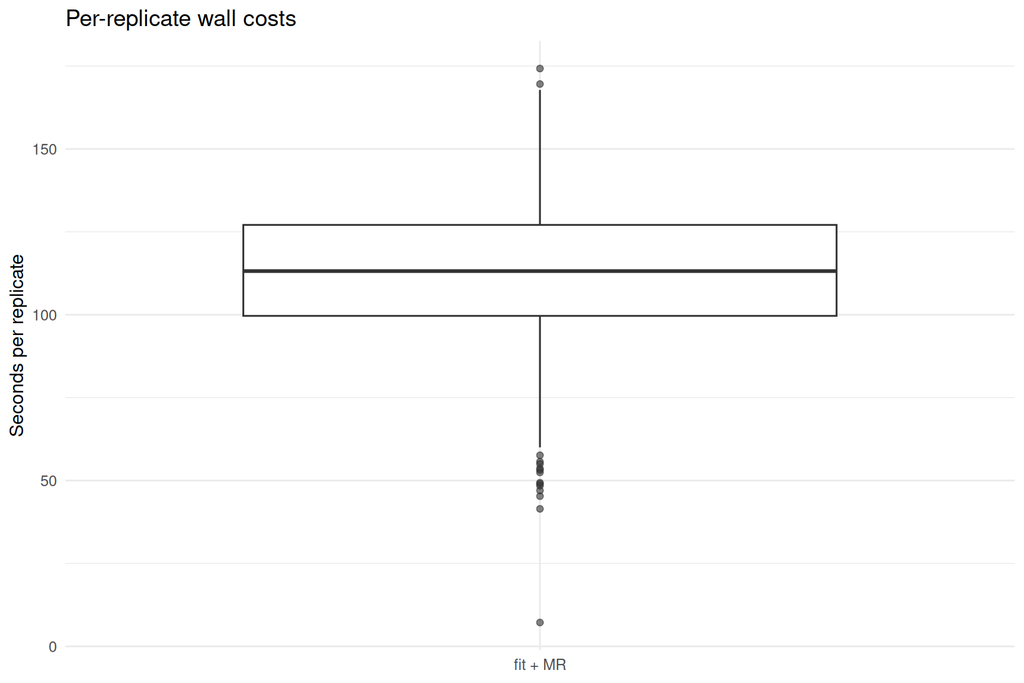

```r
.tl <- rbind(data.frame(component = "fit + MR",     secs = results$fit_mr_secs),
             data.frame(component = "FB bootstrap", secs = results$fb_secs))
.tl <- .tl[is.finite(.tl$secs), , drop = FALSE]
if (nrow(.tl)) {
  ggplot(.tl, aes(x = component, y = secs)) +
    geom_boxplot(outlier.alpha = 0.6) +
    labs(x = NULL, y = "Seconds per replicate", title = "Per-replicate wall costs") +
    theme_minimal(base_size = 12)
}
```

```r
if (run_smoke && !is.null(results)) {
  # NB: the whole forestsearch() call -- the search PLUS MR -- which is the
  # cost FB is then measured on top of.  MR's own cost alone is in
  # fs.est$mr_inference$timing_seconds.
  mr_mean  <- mean(results$fit_mr_secs, na.rm = TRUE)          # forestsearch fit + MR, per rep
  det_rate <- mean(results$detected, na.rm = TRUE)
  # FB timing only when FB actually ran; nb_boots may be 0L or NULL.
  boots_disp <- if (run_fb) as.integer(nb_boots) else 0L
  fb_mean  <- if (run_fb) mean(results$fb_secs, na.rm = TRUE) else NA_real_
  per_boot <- if (run_fb && boots_disp > 0L) fb_mean / boots_disp else NA_real_

  fmt_hm <- function(sec) {
    if (!is.finite(sec)) return("\u2014")                       # no timing available
    h <- floor(sec / 3600); m <- round((sec - 3600 * h) / 60)
    if (h >= 1) sprintf("%d h %02d m", h, m) else sprintf("%d m", round(sec / 60))
  }

  # Per-rep total cost (MR every rep; FB on the det_rate fraction only).
  per_rep_total <- function(B) {
    fb_rep <- if (run_fb && is.finite(per_boot)) per_boot * B else 0
    mr_mean + det_rate * fb_rep
  }
  # Modelled wall-clock, by parallel_mode:
  #  "sims"  -> replicates fan out, so the busiest worker handles ceil(ns/n_workers)
  #             reps and sets the wall (the integer ceiling matters at smoke-test
  #             scale, where ns can be < n_workers).
  #  "boots" -> replicates run sequentially, so the wall is their sum (ns * per-rep);
  #             the parallelism is already inside per_rep_total via the measured
  #             (parallel) bootstrap time.
  wall_model <- function(ns, B) {
    if (identical(parallel_mode, "boots")) ns * per_rep_total(B)
    else ceiling(ns / n_workers) * per_rep_total(B)
  }

  # Calibration: the busiest-worker model still omits load imbalance, per-rep
  # variance, and fixed overhead (pool spin-up, gc, dispatch, DGM build, table
  # render).  In BATCH mode we have a measured wall clock, so calibrate ONE
  # multiplier k = elapsed / wall_model(current run) and apply it to every
  # projection: by construction the current-run calibrated wall equals the
  # measured wall, and projections inherit this run's realized overhead.  In
  # COMBINE mode there is no single wall clock, so k is undefined and the
  # calibrated column is left blank.
  wall_model_cur <- wall_model(n_sims, boots_disp)
  k_cal <- if (is.finite(elapsed) && is.finite(wall_model_cur) && wall_model_cur > 0)
             elapsed / wall_model_cur else NA_real_

  proj_row <- function(ns, B, actual_sec = NA_real_) {
    fb_rep  <- if (run_fb && is.finite(per_boot)) per_boot * B else NA_real_
    cpu_sec <- ns * per_rep_total(B)                           # total serial CPU-seconds
    w_model <- wall_model(ns, B)                               # busiest-worker idealization
    w_cal   <- if (is.finite(k_cal)) k_cal * w_model else NA_real_
    data.frame(n_sims = ns, B = as.integer(B),
               mr_rep_s = round(mr_mean, 1),
               fb_rep_s = if (is.finite(fb_rep)) round(fb_rep, 0) else NA_real_,
               cpu_hours = round(cpu_sec / 3600, 1),
               wall_actual = fmt_hm(actual_sec),
               wall_model  = fmt_hm(w_model),
               wall_cal    = fmt_hm(w_cal),
               stringsAsFactors = FALSE)
  }
  cur <- proj_row(n_sims, boots_disp, actual_sec = elapsed)
  scn <- do.call(rbind, lapply(proj_scenarios,
                               function(s) proj_row(s[["n_sims"]], s[["nb_boots"]])))
  tab <- rbind(cbind(Scenario = "current run", cur),
               cbind(Scenario = "projection",  scn))

  run_label <- if (is.finite(elapsed))
    sprintf("%d reps in %.0f s on %d workers", n_sims, elapsed, n_workers)
  else
    sprintf("%d reps pooled from batch files (no single wall-clock)", n_sims)
  if (run_fb) {
    cat(sprintf(
      "Current run: %s. Per rep: fit+MR %.1f s, FB %.0f s (B=%d, ~%.1f s/bootstrap). Detection %.0f%%.\n",
      run_label, mr_mean, fb_mean, boots_disp, per_boot, 100 * det_rate))
  } else {
    cat(sprintf(
      "Current run: %s. Per rep: fit+MR %.1f s (FB skipped). Detection %.0f%%.\n",
      run_label, mr_mean, 100 * det_rate))
  }
  if (is.finite(k_cal))
    cat(sprintf("Realized overhead factor k = %.2f (measured wall / busiest-worker model).\n", k_cal))

  gt(tab) |>
    tab_header(title = "Wall-clock projection",
               subtitle = sprintf("%s mode \u00b7 %d workers \u00b7 detection %.0f%%%s",
                                  parallel_mode, n_workers, 100 * det_rate,
                                  if (is.finite(k_cal)) sprintf(" \u00b7 k = %.2f", k_cal) else "")) |>
    cols_label(n_sims = "sims", B = "boots", mr_rep_s = "fit+MR/rep (s)",
               fb_rep_s = "FB/rep (s)", cpu_hours = "CPU-hours",
               wall_actual = "wall (actual)",
               wall_model = "wall (modeled)", wall_cal = "wall (calibrated)") |>
    tab_footnote(footnote = md(paste(
      "`wall (actual)` is the **measured** wall-clock for the current run",
      "(\u2014 for projections, and in combine mode, which have no single wall-clock).",
      if (identical(parallel_mode, "boots"))
        "`wall (modeled)` = sims \u00d7 per-rep cost (replicates sequential; the bootstrap parallelizes inside each), where per-rep cost ="
      else
        "`wall (modeled)` = ceil(sims / workers) \u00d7 per-rep cost (replicates parallel, bootstrap sequential), where per-rep cost =",
      if (run_fb)
        "fit+MR/rep + detection \u00d7 FB/rep (FB/rep = per-bootstrap cost \u00d7 boots);"
      else
        "fit+MR/rep (FB skipped);",
      "It omits load imbalance and fixed overhead.",
      "`wall (calibrated)` = k \u00d7 modeled, with k = measured wall / modeled wall on THIS run,",
      "so the current row reproduces the measured wall and projections carry this run's realized overhead.",
      "`CPU-hours` = sims \u00d7 per-rep cost (total serial work).")))
}
```

```
Current run: 2000 reps pooled from batch files (no single wall-clock). Per rep: fit+MR 112.9 s (FB skipped). Detection 100%.
```

Wall-clock projection

sims mode · 60 workers · detection 100%

| Scenario | sims | boots | fit+MR/rep (s) | FB/rep (s) | CPU-hours | wall (actual) | wall (modeled) | wall (calibrated) |
| --- | --- | --- | --- | --- | --- | --- | --- | --- |
| current run | 2000 | 0 | 112.9 | NA | 62.7 | — | 1 h 04 m | — |
| projection | 100 | 300 | 112.9 | NA | 3.1 | — | 4 m | — |
| projection | 500 | 300 | 112.9 | NA | 15.7 | — | 17 m | — |
| projection | 10000 | 500 | 112.9 | NA | 313.7 | — | 5 h 14 m | — |

`wall (actual)` is the **measured** wall-clock for the current run (— for projections, and in combine mode, which have no single wall-clock). `wall (modeled)` = ceil(sims / workers) × per-rep cost (replicates parallel, bootstrap sequential), where per-rep cost = fit+MR/rep (FB skipped); It omits load imbalance and fixed overhead. `wall (calibrated)` = k × modeled, with k = measured wall / modeled wall on THIS run, so the current row reproduces the measured wall and projections carry this run’s realized overhead. `CPU-hours` = sims × per-rep cost (total serial work).

# 10 Subgroup sizes

```r
if (run_smoke && !is.null(results)) {
  rH <- results[results$detected == 1, , drop = FALSE]
  nH <- rH$n_harm[is.finite(rH$n_harm)]
  if (length(nH)) {
    nHc <- n_sample - nH
    .fmt <- function(v) sprintf(
      "mean %.0f (SD %.0f), range [%d, %d], %.1f%% of ITT",
      mean(v), stats::sd(v), as.integer(min(v)), as.integer(max(v)),
      100 * mean(v) / n_sample)
    has_true <- "n_true" %in% names(rH) && any(is.finite(rH$n_true))

    cat(sprintf(
      "\n::: {.callout-note title=\"Identified subgroup sizes (%d of %d replicates detected, N = %d each)\"}\n\n",
      nrow(rH), nrow(results), n_sample))
    cat(sprintf("- **Harm $\\widehat H$**: %s\n", .fmt(nH)))
    cat(sprintf("- **Complement $\\widehat H^{c}$**: %s\n", .fmt(nHc)))
    if (has_true) {
      nT <- rH$n_true[is.finite(rH$n_true)]
      cat(sprintf("- **True harm $Q$**: %s\n", .fmt(nT)))
      cat(sprintf(
        "\nThe identified $\\widehat H$ averages **%.1f%%** of ITT against a true harm prevalence of **%.1f%%**; this small-subgroup regime is what stresses the large-sample behaviour of the MR.\n",
        100 * mean(nH) / n_sample, 100 * mean(nT) / n_sample))
    } else {
      cat(sprintf(
        "\nThe identified $\\widehat H$ averages **%.1f%%** of ITT (the true harm subgroup is ~11%% of ITT by design); this small-subgroup regime is what stresses the large-sample behaviour of the MR.\n",
        100 * mean(nH) / n_sample))
    }
    cat("\n:::\n\n")
  } else {
    cat("\n::: {.callout-note title=\"Identified subgroup sizes\"}\nNo subgroup was identified on any replicate, so no $\\widehat H$ sizes are available.\n:::\n\n")
  }
}
```

**NoteIdentified subgroup sizes (1999 of 2000 replicates detected, N = 500 each)**

- **Harm $\widehat H$**: mean 124 (SD 37), range [61, 280], 24.8% of ITT
- **Complement $\widehat H^{c}$**: mean 376 (SD 37), range [220, 439], 75.2% of ITT
- **True harm $Q$**: mean 153 (SD 10), range [124, 191], 30.6% of ITT

The identified $\widehat H$ averages **24.8%** of ITT against a true harm prevalence of **30.6%**; this small-subgroup regime is what stresses the large-sample behaviour of the MR.

```r
# Re-selection regime and family/band sizes (TASK_p30sg_nb20_2026-09-07;
# add-only: renders nothing on bundles recorded before the p_hat_* columns).
if (run_smoke && !is.null(results) && "p_hat_H" %in% names(results)) {
  rD <- results[results$detected == 1 & is.finite(results$p_hat_H), , drop = FALSE]
  if (nrow(rD)) {
    .q <- function(v) { v <- v[is.finite(v)]; q <- stats::quantile(v, c(.25, .5, .75))
      sprintf("mean %.3f, quartiles %.3f / %.3f / %.3f", mean(v), q[1], q[2], q[3]) }
    .qi <- function(v) { v <- v[is.finite(v)]; q <- stats::quantile(v, c(.25, .5, .75))
      sprintf("mean %.1f, quartiles %.0f / %.0f / %.0f, range [%d, %d]", mean(v), q[1], q[2], q[3], as.integer(min(v)), as.integer(max(v))) }
    top3 <- rowSums(cbind(rD$p_hat_top1, rD$p_hat_top2, rD$p_hat_top3), na.rm = TRUE)
    cat(sprintf("\n::: {.callout-note title=\"Re-selection regime (gate p-hat over the kept family; %d detected replicates with p-hat recorded)\"}\n\n", nrow(rD)))
    cat(sprintf("- **p-hat($\\widehat H$)** (re-selection frequency of the selected candidate): %s; share with p-hat($\\widehat H$) = the family argmax: %.3f\n", .q(rD$p_hat_H), mean(abs(rD$p_hat_H - rD$p_hat_top1) < 1e-12)))
    cat(sprintf("- **top-3 mass** (three largest frequencies): %s; sum over the family (= selection rate): mean %.3f\n", .q(top3), mean(rD$p_hat_sum, na.rm = TRUE)))
    if (any(is.finite(rD$n_family)))    cat(sprintf("- **family size K** (gate's kept family): %s\n", .qi(rD$n_family)))
    if (any(is.finite(rD$n_cons_qual))) cat(sprintf("- **consistency-qualifying candidates**: %s\n", .qi(rD$n_cons_qual)))
    if (any(is.finite(rD$band_n)))      cat(sprintf("- **band size** (candidates with hr >= (1 - %.2f) x max hr on the observed effects): %s\n", effect_neighborhood, .qi(rD$band_n)))
    cat("\n:::\n\n")
  }
}
```

**NoteRe-selection regime (gate p-hat over the kept family; 1999 detected replicates with p-hat recorded)**

- **p-hat($\widehat H$)** (re-selection frequency of the selected candidate): mean 0.085, quartiles 0.025 / 0.054 / 0.113; share with p-hat($\widehat H$) = the family argmax: 0.212
- **top-3 mass** (three largest frequencies): mean 0.333, quartiles 0.241 / 0.314 / 0.406; sum over the family (= selection rate): mean 1.000
- **family size K** (gate’s kept family): mean 2027.4, quartiles 1944 / 2039 / 2084, range [1641, 2253]
- **consistency-qualifying candidates**: mean 314.0, quartiles 136 / 267 / 454, range [1, 1105]
- **band size** (candidates with hr >= (1 - 0.20) x max hr on the observed effects): mean 12.6, quartiles 5 / 10 / 17, range [1, 78]

# 11 Estimation / coverage table (León Table 2 layout + MR)

```r
# All summaries are finite-only: non-finite estimates/bounds (e.g. from Cox
# separation or an unstable small-B IJ) are dropped so a single blow-up cannot
# dominate a mean.
.cover <- function(target, lo, hi) {
  target <- rep_len(target, length(lo))   # recycle scalar targets (CDE/marginal) to n reps
  ok <- is.finite(target) & is.finite(lo) & is.finite(hi)
  if (!any(ok)) return(NA_real_)
  mean(target[ok] >= lo[ok] & target[ok] <= hi[ok])
}
.pbias <- function(est, target) {
  d <- (est - target) / target; d <- d[is.finite(d)]
  if (!length(d)) return(NA_real_)
  100 * mean(d)
}
.mfin <- function(x) { x <- x[is.finite(x)]; if (length(x)) mean(x) else NA_real_ }
.sdfin <- function(x) { x <- x[is.finite(x)]; if (length(x) > 1L) sd(x) else NA_real_ }
# Empirical (true) SD on the log-HR (beta) scale: SD of log(HR) across reps.
.sd_log <- function(e) { l <- log(e[is.finite(e) & e > 0]); if (length(l) > 1L) sd(l) else NA_real_ }
# Stored per-replicate log-HR (beta-scale) SE for an estimator -- read at the
# source, never back-calculated from CI bounds (or_/nv_/fb_*_se; MR uses its IJ
# SE, mr_*_se_ij).  A missing column (results saved before SEs were stored)
# yields all-NA so the table still renders.
.get_se <- function(r, k, suffix) {
  col <- if (k == "fld") paste0("fld_", suffix, "_se")
         else if (k == "mr") paste0(k, "_", suffix, "_se_ij")
         else if (k == "mrw") paste0("mr_", suffix, "_se_w")
         else if (k == "mrwf") paste0("mr_", suffix, "_se_wf")
         else paste0(k, "_", suffix, "_se")
  v <- r[[col]]
  if (is.null(v)) rep(NA_real_, nrow(r)) else v
}

# Estimator rows for one block.  FB appears whenever fb_* data exist (run OR
# joined); MR (field) appears wherever that block's field columns are present
# and finite -- the Hhat block always under ci_method = "field", the Hhat^c
# block only when the render ran with field_complement = TRUE
# (TASK_mr_field_complement_2026-09-06) -- and uses est2 with the two-sided
# quantile interval as its primary interval (decision F4).
# The two winner-only IJ rows (TASK_complement_refinements_2026-09-06) share
# MR (IJ)'s point estimate and differ only in SE/bounds; they appear when
# the bundle recorded mr_<block>_se_w.
est_keys_for <- function(r, suffix) {
  keys <- c(oracle = "or", naive = "nv", FB = "fb",
            `MR (IJ)` = "mr", `MR (IJ, winner)` = "mrw",
            `MR (IJ, winner-floor)` = "mrwf", `MR (field)` = "fld")
  if (!any(is.finite(r$fb_H_est))) keys <- keys[names(keys) != "FB"]
  if (!any(is.finite(r[[paste0("fld_", suffix, "_est2")]] %||% NA_real_)))
    keys <- keys[names(keys) != "MR (field)"]
  if (!isTRUE(show_winner_rows) ||
      !any(is.finite(r[[paste0("mr_", suffix, "_se_w")]] %||% NA_real_)))
    keys <- keys[!names(keys) %in% c("MR (IJ, winner)", "MR (IJ, winner-floor)")]
  keys
}
.est_cols <- function(r, k, suffix) {
  if (k == "fld") list(e  = r[[paste0("fld_", suffix, "_est2")]],
                       lo = r[[paste0("fld_", suffix, "_lo2s")]],
                       hi = r[[paste0("fld_", suffix, "_hi2s")]])
  else if (k %in% c("mrw", "mrwf")) {
    vs <- if (k == "mrw") "_w" else "_wf"
    list(e  = r[[paste0("mr_", suffix, "_est")]],
         lo = r[[paste0("mr_", suffix, "_lo", vs)]],
         hi = r[[paste0("mr_", suffix, "_hi", vs)]])
  }
  else list(e  = r[[paste0(k, "_", suffix, "_est")]],
            lo = r[[paste0(k, "_", suffix, "_lo")]],
            hi = r[[paste0(k, "_", suffix, "_hi")]])
}

# Build one block (H or Hc): estimator rows against the four targets.
build_block <- function(r, suffix, tgt_cde, tgt_marg) {
  est_keys <- est_keys_for(r, suffix)
  or_est <- r[[paste0("or_", suffix, "_est")]]   # per-replicate oracle target
  bH_est <- r[[paste0("betaHhat_", suffix)]]     # per-replicate beta(Hhat) target
  rows <- lapply(names(est_keys), function(lab) {
    k  <- est_keys[[lab]]
    ec <- .est_cols(r, k, suffix)
    e  <- ec$e
    lo <- ec$lo
    hi <- ec$hi
    len <- hi - lo; len <- len[is.finite(len)]
    seb <- .get_se(r, k, suffix)                  # stored log-HR (beta) SE
    data.frame(
      Estimator = lab,
      n       = sum(is.finite(e)),
      Avg     = .mfin(e),
      SD        = .sd_log(e),                      # empirical SD, log-HR (beta) scale  [reported]
      SD_hr     = .sdfin(e),                       # empirical SD, HR scale             [retained]
      SD_hat    = .mfin(seb),                      # mean model SE, log-HR (beta) scale [reported]
      SD_hat_hr = .mfin(e * seb),                  # mean model SE, HR scale            [retained]
      Length  = if (length(len)) mean(len) else NA_real_,
      b_oracle = .pbias(e, or_est),
      b_betaHhat = .pbias(e, bH_est),
      b_cde    = .pbias(e, tgt_cde),
      b_marg   = .pbias(e, tgt_marg),
      Cov_oracle = .cover(or_est, lo, hi),
      Cov_betaHhat = .cover(bH_est, lo, hi),
      Cov_cde    = .cover(tgt_cde,  lo, hi),
      Cov_marg   = .cover(tgt_marg, lo, hi),
      stringsAsFactors = FALSE)
  })
  do.call(rbind, rows)
}

if (run_smoke && !is.null(results)) {
  # FB rows render whenever fb_* data exist -- computed (fb_mode "run") or
  # adopted from the committed bundle (fb_mode "join").  run_fb alone cannot
  # gate this: it is FALSE under "join".
  fb_in_tables <- any(is.finite(results$fb_H_est))
  rH  <- results[results$detected == 1, , drop = FALSE]
  blockH  <- build_block(rH, "H",  truth$cde_H,  truth$marg_H)
  blockHc <- build_block(rH, "Hc", truth$cde_Hc, truth$marg_Hc)
  # Fold the mean identified subgroup size into the block label, so |H-hat|
  # travels with the table (as in build_estimation_table()'s row-group labels).
  .blk_lab <- function(label, sym, v) {
    if (!any(is.finite(v))) return(label)
    sprintf("%s (mean |%s| = %.0f, %.1f%% ITT)", label, sym,
            mean(v, na.rm = TRUE), 100 * mean(v, na.rm = TRUE) / n_sample)
  }
  est_tab <- rbind(
    cbind(Block = .blk_lab("Harm  \u0124", "\u0124", rH$n_harm), blockH),
    cbind(Block = .blk_lab("Complement  \u0124\u1d9c", "\u0124\u1d9c",
                           n_sample - rH$n_harm), blockHc)
  )

  det_rate <- mean(results$detected, na.rm = TRUE)
  # Classification + decision + IJ-stability diagnostics (over detected reps).
  cls <- sprintf("sens %.2f \u00b7 spec %.2f \u00b7 PPV %.2f \u00b7 NPV %.2f",
                 .mfin(rH$sens), .mfin(rH$spec), .mfin(rH$ppv), .mfin(rH$npv))
  # MR availability: the share of DETECTED reps for which MR returned an object.
  # The detected-only denominator is what makes this mean "MR failed" rather than
  # "nothing was found": .na_record() sets mr_ok = 0L, so every undetected rep
  # also carries mr_ok = 0 and an unconditional mean would just reproduce the
  # detection rate.  Reported because mr_ok is otherwise invisible -- a run where
  # MR failed on a third of the detected reps would read identically to one where
  # it never failed.
  mr_avail  <- mean(rH$mr_ok, na.rm = TRUE)
  # Both of the following are ALREADY conditional on MR having run: mr_harm_flag
  # and ij_source stay NA when g is NULL, and na.rm = TRUE drops those reps.  So
  # their denominator is mr_avail * |detected|, not |detected| -- which is why
  # availability is stated first and these two read "among those".
  harm_rate <- mean(rH$mr_harm_flag, na.rm = TRUE)
  ij_ok     <- mean(rH$ij_source == "ij", na.rm = TRUE)

  gt(est_tab, groupname_col = "Block") |>
    tab_header(
      title = if (fb_in_tables)
        "FB vs MR (IJ) vs MR (field): estimation & coverage"
      else "MR (IJ) vs MR (field): estimation & coverage",
      subtitle = sprintf("hr=%.2f \u00b7 n=%d, %d sims, draws=%d \u00b7 fb_mode=%s \u00b7 resample identification",
                         target_hr_harm, n_sample, n_sims, mr_draws, fb_mode)) |>
    fmt_number(columns = c(Avg, SD, SD_hr, SD_hat, SD_hat_hr, Length), decimals = 2) |>
    fmt_number(columns = c(b_oracle, b_betaHhat, b_cde, b_marg), decimals = 1) |>
    fmt_number(columns = c(Cov_oracle, Cov_betaHhat, Cov_cde, Cov_marg), decimals = 2) |>
    cols_label(
      n = "n",
      SD = md("$\\text{SD}_{\\beta}$"), SD_hat = md("$\\widehat{\\text{SD}}_{\\beta}$"),
      b_oracle = md("$b^{\\text{or}}$"), b_betaHhat = md("$b^{\\beta}$"),
      b_cde = md("$b^{\\ddagger}$"), b_marg = md("$b^{\\dagger}$"),
      Cov_oracle = md("$\\hat{C}^{\\text{or}}$"), Cov_betaHhat = md("$\\hat{C}^{\\beta}$"),
      Cov_cde = md("$\\hat{C}^{\\ddagger}$"), Cov_marg = md("$C^{\\dagger}$")) |>
    cols_hide(columns = c(SD_hr, SD_hat_hr)) |>
    tab_spanner(label = "Relative bias (%)", columns = c(b_oracle, b_betaHhat, b_cde, b_marg)) |>
    tab_spanner(label = "95% coverage", columns = c(Cov_oracle, Cov_betaHhat, Cov_cde, Cov_marg)) |>
    tab_footnote(footnote = md(sprintf(
      "Detection rate **%.0f%%** of %d sims; MR returned an estimate on **%.0f%%** of detected reps; among those, MR flags harm in **%.0f%%** and IJ variance held (not fallback) in **%.0f%%**. Classification of \u0124 vs true subgroup: %s. Summaries finite-only over detected reps; `n` = finite reps contributing.",
      100 * det_rate, n_sims, 100 * mr_avail, 100 * harm_rate, 100 * ij_ok, cls))) |>
    tab_footnote(footnote = md(paste(
      "$\\text{SD}_{\\beta}$ (empirical SD) and $\\widehat{\\text{SD}}_{\\beta}$ (mean of the model SEs) are on the log-hazard-ratio ($\\beta$) scale; HR-scale versions are computed but hidden.",
      "Targets: $b^{\\text{or}}$ vs per-replicate oracle $\\hat\\theta(H)$;",
      "$b^{\\beta}$ / $\\hat C^{\\beta}$ vs the conditional subgroup HR $\\beta(\\widehat H)$ at the realized region (Theorem 2 target);",
      "$b^{\\ddagger}$ vs CDE $\\theta^{\\ddagger}$;",
      "$b^{\\dagger}$ vs marginal subgroup HR $\\theta^{\\dagger}$.",
      "`Length` = mean CI length.",
      if (fb_in_tables)
        "FB = `H2` (León Eq.7, both bias sources); MR (IJ) = de-biased estimate with IJ interval; MR (field) = shrunk-field `est2` with the two-sided 95% Lambda-quantile interval (its SE column is the Lambda-SD `se_field`). The field is computed for the Hhat block only (F3); Hhat-c stays on the IJ interval."
      else
        "MR (IJ) = de-biased estimate with IJ interval; MR (field) = shrunk-field `est2` with the two-sided 95% Lambda-quantile interval (its SE column is the Lambda-SD `se_field`); field is Hhat-block only (F3). FB absent in this cell/range.")))
}
```

MR (IJ) vs MR (field): estimation & coverage